# クリーンアーキテクチャ完全ガイド

### 7.2.3 ❌ 2. 密結合（Tight Coupling）

#### 7.2.3.1 🎯 問題

層間の依存関係が逆向きになり、下位層が上位層を参照する。

#### 7.2.3.2 📍 具体例

```typescript
// 🚫 アンチパターン：密結合

// domain/User.ts（ドメイン層）
import { Database } from '../infrastructure/database'; // ❌ 上位層への依存

export class User {
  id: string;
  email: string;

  async save() {
    // ドメイン層が DB を直接操作
    await Database.instance.query(
      'INSERT INTO users (id, email) VALUES (?, ?)',
      [this.id, this.email]
    );
  }
}

// application/SaveUserUseCase.ts（アプリケーション層）
import { User } from '../domain/User';
import { NotificationService } from '../infrastructure/NotificationService';

export class SaveUserUseCase {
  async execute(email: string) {
    const user = new User(email);
    // インフラ層の具体的な実装に依存
    await user.save();

    // その他のインフラも直接参照
    await NotificationService.send(email);
  }
}
```

#### 7.2.3.3 ✅ 解決策

```typescript
// 依存関係を逆転させる

// domain/User.ts（ドメイン層）
export class User {
  constructor(
    public id: string,
    public email: Email
  ) {}

  // ドメインロジックのみ
  isActive(): boolean {
    return !!this.email;
  }
}

// domain/ports/UserRepository.ts（インターフェース）
export interface UserRepository {
  save(user: User): Promise<void>;
  getById(id: string): Promise<User | null>;
}

// application/SaveUserUseCase.ts（アプリケーション層）
export class SaveUserUseCase {
  constructor(
    private userRepository: UserRepository,  // 抽象に依存
    private notificationService: NotificationService
  ) {}

  async execute(email: string): Promise<void> {
    const user = new User(uuid(), new Email(email));
    await this.userRepository.save(user);
    await this.notificationService.notifyUserCreated(user);
  }
}

// infrastructure/repositories/MySQLUserRepository.ts（実装）
export class MySQLUserRepository implements UserRepository {
  constructor(private connection: Pool) {}

  async save(user: User): Promise<void> {
    await this.connection.query(
      'INSERT INTO users (id, email) VALUES (?, ?)',
      [user.id, user.email.value]
    );
  }
}
```

#### 7.2.3.4 📋 検出方法

```bash
# 循環依存をチェック
npm install --save-dev madge
npx madge --circular src/

# 依存グラフを可視化
npx madge --image graph.png src/
```

### 7.2.4 ❌ 3. 貧血モデル（Anemic Model）

#### 7.2.4.1 🎯 問題

エンティティがデータフィールドのみで、ビジネスロジックを持たない。ロジックが Use Case や Service に散在。

#### 7.2.4.2 📍 具体例

```typescript
// 🚫 アンチパターン：貧血モデル

// domain/Account.ts
export class Account {
  id: string;
  userId: string;
  balance: number;  // ただのデータ
  createdAt: Date;

  constructor(id: string, userId: string, balance: number) {
    this.id = id;
    this.userId = userId;
    this.balance = balance;
    this.createdAt = new Date();
  }
}

// ビジネスロジックかSERVICEに散在
// application/TransferUseCase.ts
export class TransferUseCase {
  async execute(fromId: string, toId: string, amount: number) {
    const from = await this.accountRepository.getById(fromId);
    const to = await this.accountRepository.getById(toId);

    // ロジックがユースケースに散在 ❌
    if (from.balance < amount) {
      throw new Error('Insufficient balance');
    }

    from.balance -= amount;  // データを直接変更
    to.balance += amount;

    await this.accountRepository.update(from);
    await this.accountRepository.update(to);
  }
}

// 別のサービスでも同じロジック...
// domain/AccountService.ts
export class AccountService {
  calculateInterest(account: Account): number {
    return account.balance * 0.05;  // 利息計算
  }
}
```

#### 7.2.4.3 ✅ 解決策

```typescript
// ✅ リッチモデル：ロジックをエンティティに集約

// domain/Account.ts
export class Account {
  constructor(
    public id: string,
    public userId: string,
    private balance: Money  // 値オブジェクト
  ) {}

  // ビジネスロジックをメソッド化
  transfer(amount: Money): void {
    if (this.balance.isLessThan(amount)) {
      throw new InsufficientBalanceError(
        `Required: ${amount.value}, Available: ${this.balance.value}`
      );
    }
    this.balance = this.balance.subtract(amount);
  }

  deposit(amount: Money): void {
    this.balance = this.balance.add(amount);
  }

  calculateInterest(rate: number): Money {
    return this.balance.multiply(rate);
  }

  // クエリメソッド
  getBalance(): Money {
    return this.balance;
  }
}

// application/TransferUseCase.ts
export class TransferUseCase {
  constructor(
    private accountRepository: AccountRepository
  ) {}

  async execute(fromId: string, toId: string, amount: Money): Promise<void> {
    const from = await this.accountRepository.getById(fromId);
    const to = await this.accountRepository.getById(toId);

    // エンティティがロジックを持つ
    from.transfer(amount);
    to.deposit(amount);

    await this.accountRepository.update(from);
    await this.accountRepository.update(to);
  }
}
```

#### 7.2.4.4 📋 判断基準

```
✅ リッチモデルに向く場合
- ビジネスロジックが複雑
- ドメインルールが増加傾向
- 複数のエンティティで同じロジック

❌ 貧血モデルが許容される場合
- CRUD アプリケーション
- ロジックほぼなし
- プロトタイプ段階
```

### 7.2.5 ❌ 4. 循環依存（Circular Dependency）

#### 7.2.5.1 🎯 問題

A が B を参照し、B が A を参照する或いは複数モジュールで循環している。

#### 7.2.5.2 📍 具体例

```typescript
// 🚫 アンチパターン：循環依存

// domain/User.ts
import { Account } from './Account';  // ← Account を参照

export class User {
  accounts: Account[] = [];

  getBalance(): number {
    return this.accounts.reduce((sum, acc) => sum + acc.getBalance(), 0);
  }
}

// domain/Account.ts
import { User } from './User';  // ← User を参照（循環！）

export class Account {
  owner: User;

  constructor(owner: User) {
    this.owner = owner;
    owner.accounts.push(this);  // 相互参照
  }
}
```

#### 7.2.5.3 ✅ 解決策

```typescript
// 方法1：インターフェースで分離
// domain/ports/Account.ts
export interface Account {
  getBalance(): number;
}

// domain/User.ts
export class User {
  constructor(private accounts: Account[]) {}

  getTotalBalance(): number {
    return this.accounts.reduce((sum, acc) => sum + acc.getBalance(), 0);
  }
}

// domain/UserAccount.ts
export class UserAccount implements Account {
  constructor(
    public id: string,
    public balance: number,
    public userId: string
  ) {}

  getBalance(): number {
    return this.balance;
  }
}

// 方法2：中間層で参照を遅延
// application/services/UserAccountService.ts
export class UserAccountService {
  constructor(
    private userRepository: UserRepository,
    private accountRepository: AccountRepository
  ) {}

  async getTotalBalance(userId: string): Promise<number> {
    const accounts = await this.accountRepository.findByUserId(userId);
    return accounts.reduce((sum, acc) => sum + acc.balance, 0);
  }
}
```

### 7.2.6 📋 総合チェックリスト

```
循環依存の検出
✅ madge で循環参照なし
✅ モジュール分割が明確
✅ 依存関係が一方向

密結合の排除
✅ ドメイン層が上位層を参照していない
✅ インターフェース経由の依存
✅ DI コンテナの活用

豊富なドメインモデル
✅ ビジネスロジックをエンティティに含む
✅ 値オブジェクトが使われている
✅ Use Case は層の仲介のみ

適切な複雑さ
✅ 現在のプロジェクト規模に合った設計
✅ 過度な抽象化がない
✅ チーム全体で理解できている
```

### 7.2.7 🔗 関連セクション

- 実装ガイド - 正しい実装方法
- ベストプラクティス - 品質向上
- ケーススタディ - 実装例

**次: ケーススタディ →**

## 7.3 密結合（Tight Coupling）

層間の依存関係を逆転させて疎結合を実現する。

### 7.3.1 🎯 問題

下位層が上位層を参照する、または層間の依存が双方向になると： - テスト困難（実装に依存） - 変更範囲が不確定（連鎖的に影響） - 再利用不可（依存が特定実装に限定）

### 7.3.2 📍 具体例：密結合アンチパターン

```typescript
// 🚫 ドメイン層がインフラ層に依存

// domain/User.ts（ドメイン層）
import { Database } from '../infrastructure/database';  // ❌ 上位層への参照

export class User {
  id: string;
  email: string;

  async save() {
    // DB を直接操作
    await Database.instance.query(
      'INSERT INTO users (id, email) VALUES (?, ?)',
      [this.id, this.email]
    );
  }
}

// application/SaveUserUseCase.ts（アプリケーション層）
import { User } from '../domain/User';
import { NotificationService } from '../infrastructure/NotificationService';

export class SaveUserUseCase {
  async execute(email: string) {
    const user = new User(email);
    // インフラ層の具体的な実装に直接依存
    await user.save();

    // Service もベタ参照
    await NotificationService.send(email);
  }
}

// 🔴 テストが困難
// Domain をテストするのに、Database が必須
import { User } from '../domain/User';

describe('User', () => {
  it('should save user', async () => {
    const user = new User('john@example.com');
    await user.save();  // ← DB が必須
    // モック化不可
  });
});
```

**問題の内容：** - ドメイン = data + behavior - infrastructure = 実装詳細

この2つが混在すると、テストや再利用が困難になる

### 7.3.3 ✅ 解決策：依存関係の逆転

#### 7.3.3.1 原則：依存は下位層（抽象度↑）へ

```
Presentation → Application → Domain ← Infrastructure
                                ↑
                             依存の向き
```

**各層で参照可能なもの：** - Presentation: Application のみ - Application: Domain のみ - Domain: Domain のみ（他層は参照禁止） - Infrastructure: Domain（インターフェースを実装するため依存）+ 外部ライブラリ

#### 7.3.3.2 実装例：インターフェース経由

```typescript
// domain/ports/UserRepository.ts（インターフェース）
export interface UserRepository {
  save(user: User): Promise<void>;
  getById(id: string): Promise<User | null>;
}

// domain/User.ts（ドメイン層）
export class User {
  constructor(
    public id: string,
    public email: Email  // 値オブジェクト
  ) {}

  // ドメインロジックのみ
  isActive(): boolean {
    return this.email != null;
  }

  sendWelcomeEmail(): void {
    // ❌このロジックはドメインに含めない
    // インフラの詳細になるため
  }
}

// application/SaveUserUseCase.ts（アプリケーション層）
export class SaveUserUseCase {
  constructor(
    private userRepository: UserRepository,  // ✅ インターフェース依存
    private notificationService: NotificationService
  ) {}

  async execute(email: string): Promise<void> {
    // ドメインロジック
    const emailObj = new Email(email);
    const user = new User(uuid(), emailObj);

    // リポジトリを通じて永続化
    await this.userRepository.save(user);

    // 副作用を処理
    await this.notificationService.notifyUserCreated(user);
  }
}

// infrastructure/repositories/MySQLUserRepository.ts
export class MySQLUserRepository implements UserRepository {
  constructor(private connection: Pool) {}

  async save(user: User): Promise<void> {
    await this.connection.query(
      'INSERT INTO users (id, email) VALUES (?, ?)',
      [user.id, user.email.getValue()]
    );
  }

  async getById(id: string): Promise<User | null> {
    const [rows] = await this.connection.query(
      'SELECT * FROM users WHERE id = ?',
      [id]
    );
    if (!rows[0]) return null;

    return new User(rows[0].id, new Email(rows[0].email));
  }
}

// infrastructure/adapters/SendgridNotificationService.ts
import { httpClient } from '../http';

export class SendgridNotificationService implements NotificationService {
  async notifyUserCreated(user: User): Promise<void> {
    await httpClient.post('https://api.sendgrid.com/v3/mail/send', {
      to: user.email.getValue(),
      subject: 'Welcome!',
      html: '<h1>Welcome to our app</h1>'
    });
  }
}
```

#### 7.3.3.3 テスト：インターフェース を使ったモック

```typescript
// tests/usecases/SaveUserUseCase.test.ts
describe('SaveUserUseCase', () => {
  let useCase: SaveUserUseCase;
  let mockRepository: UserRepository;
  let mockNotificationService: NotificationService;

  beforeEach(() => {
    // モック実装
    mockRepository = {
      save: jest.fn(),
      getById: jest.fn()
    };

    mockNotificationService = {
      notifyUserCreated: jest.fn()
    };

    useCase = new SaveUserUseCase(
      mockRepository,
      mockNotificationService
    );
  });

  it('should save user and send notification', async () => {
    // ✅ DB なしでテスト可能
    await useCase.execute('john@example.com');

    expect(mockRepository.save).toHaveBeenCalledWith(
      expect.objectContaining({
        email: expect.any(Email)
      })
    );

    expect(mockNotificationService.notifyUserCreated).toHaveBeenCalled();
  });

  it('should throw error for invalid email', async () => {
    // ドメイン層のバリデーション
    await expect(useCase.execute('invalid-email')).rejects.toThrow(
      InvalidEmailError
    );
  });
});
```

### 7.3.4 🔄 よくある密結合パターンと修正

#### 7.3.4.1 パターン1：グローバルゴブリン

```typescript
// ❌ グローバルインスタンスへの依存
// config/Database.ts
export class Database {
  static instance = new Pool();  // シングルトン
}

// domain/User.ts
import { Database } from '../config/Database';
export class User {
  async save() {
    await Database.instance.query(...);  // グローバル参照
  }
}

// ✅ コンストラクタで注入
// domain/User.ts
export class User {
  // リポジトリインターフェースとして依存
}

// application/SaveUserUseCase.ts
export class SaveUserUseCase {
  constructor(private userRepository: UserRepository) {}
  // リポジトリは DI コンテナから来る
}
```

#### 7.3.4.2 パターン2：具体的なクラスに依存

```typescript
// ❌ 具体実装に依存
import { MySQLUserRepository } from '../infrastructure/MySQLUserRepository';

export class SaveUserUseCase {
  private repository = new MySQLUserRepository();
}

// ✅ インターフェースに依存
import { UserRepository } from '../domain/ports/UserRepository';

export class SaveUserUseCase {
  constructor(private userRepository: UserRepository) {}
  // MongoDB に切り替えも簡単
}
```

#### 7.3.4.3 パターン3：層を超えた直接参照

```typescript
// ❌ Presentation が直接 Infrastructure を参照
import { MySQLUserRepository } from '../infrastructure/MySQLUserRepository';

export class UserController {
  private repository = new MySQLUserRepository();

  async getUser(req: Request, res: Response) {
    const user = await this.repository.getById(req.params.id);
    res.json(user);
  }
}

// ✅ Application を経由
import { GetUserUseCase } from '../application/GetUserUseCase';

export class UserController {
  constructor(private getUserUseCase: GetUserUseCase) {}

  async getUser(req: Request, res: Response) {
    const user = await this.getUserUseCase.execute(req.params.id);
    res.json(user);
  }
}
```

### 7.3.5 🔍 密結合の検出

#### 7.3.5.1 madge で循環・密結合を検出

```bash
npm install --save-dev madge

# 循環依存をチェック
npx madge --circular src/

# 詳細な依存グラフを表示
npx madge src/

# グラフ画像を生成
npx madge --image graph.png src/
```

**出力例：**

```
⚠️  Circular dependencies found:
  A → B → A

❌ domain/User → infrastructure/Database → domain/User
```

### 7.3.6 📋 チェックリスト

```
✅ ドメイン層は他層を参照していない
✅ 依存関係がわかりやすい DAG（有向非巡回グラフ）
✅ インターフェース経由で層を分離
✅ DI コンテナで依存を一元管理
✅ テストでモックが使える
✅ madge で循環依存がない
✅ 層の責務が明確
```

**次: 貧血モデルの回避 →**

## 7.4 貧血モデル（Anemic Model）

ビジネスロジックをエンティティに戻す（リッチモデル設計）。

### 7.4.1 🎯 問題

エンティティがデータフィールドのみで、ビジネスロジックを持たない。

**結果：** - ロジックが Use Case や Service に散在 - ロジックの重複 - バグが増加（検証が漏れる） - ドメイン知識が散在

### 7.4.2 📍 具体例：貧血モデル

```typescript
// 🚫 エンティティがただのデータホルダー

// domain/Account.ts
export class Account {
  id: string;
  userId: string;
  balance: number;        // ただのフィールド
  createdAt: Date;

  constructor(id: string, userId: string, balance: number) {
    this.id = id;
    this.userId = userId;
    this.balance = balance;
    this.createdAt = new Date();
  }
}

// ビジネスロジックが各所に散在

// application/TransferUseCase.ts
export class TransferUseCase {
  async execute(fromId: string, toId: string, amount: number) {
    const from = await this.accountRepository.getById(fromId);
    const to = await this.accountRepository.getById(toId);

    // ロジックがユースケースに ❌
    if (from.balance < amount) {
      throw new Error('Insufficient balance');
    }

    from.balance -= amount;   // データ直操作
    to.balance += amount;

    await this.accountRepository.update(from);
    await this.accountRepository.update(to);
  }
}

// application/WithdrawUseCase.ts
export class WithdrawUseCase {
  async execute(accountId: string, amount: number) {
    const account = await this.accountRepository.getById(accountId);

    // 同じロジックを重複
    if (account.balance < amount) {
      throw new Error('Insufficient balance');
    }

    account.balance -= amount;   // 毎回同じ処理

    await this.accountRepository.update(account);
  }
}

// domain/AccountService.ts（さらにロジックが分散）
export class AccountService {
  calculateInterest(account: Account): number {
    return account.balance * 0.05;
  }

  applyMonthlyFee(account: Account): void {
    account.balance -= 10;  // 手数料
  }
}

// 🔴 問題：
// 1. 検証ロジックが複数箇所に存在 → バグ削減困難
// 2. ロジックが一貫していない
//    （TransferUseCase では < だが、別の場所では ≤ かもしれない）
// 3. ビジネスルールがどこにあるか不明
// 4. テストが複雑（モック設定多い）
```

### 7.4.3 ✅ 解決策：リッチモデル

#### 7.4.3.1 ステップ1：値オブジェクトを導入

```typescript
// domain/value-objects/Money.ts
export class Money {
  constructor(public readonly value: number) {
    if (value < 0) {
      throw new Error('Money cannot be negative');
    }
  }

  add(other: Money): Money {
    return new Money(this.value + other.value);
  }

  subtract(other: Money): Money {
    if (other.value > this.value) {
      throw new InsufficientBalanceError(
        `Cannot subtract ${other.value} from ${this.value}`
      );
    }
    return new Money(this.value - other.value);
  }

  multiply(rate: number): Money {
    return new Money(this.value * rate);
  }

  isLessThan(other: Money): boolean {
    return this.value < other.value;
  }

  isGreaterThanOrEqual(other: Money): boolean {
    return this.value >= other.value;
  }
}
```

#### 7.4.3.2 ステップ2：ロジックをエンティティに移動

```typescript
// domain/Account.ts（リッチモデル）
export class Account {
  constructor(
    public id: string,
    public userId: string,
    private balance: Money,  // 値オブジェクト
    public createdAt: Date
  ) {}

  // ✅ ビジネスロジックをメソッド化

  /**
   * 出金処理
   * @throws InsufficientBalanceError
   */
  withdraw(amount: Money): void {
    this.balance = this.balance.subtract(amount);  // 検証含む
  }

  /**
   * 入金処理
   */
  deposit(amount: Money): void {
    this.balance = this.balance.add(amount);
  }

  /**
   * 振替処理（出金側）
   */
  withdrawForTransfer(amount: Money): void {
    this.withdraw(amount);
  }

  /**
   * 振替処理（入金側）
   */
  receiveTransfer(amount: Money): void {
    this.deposit(amount);
  }

  /**
   * 利息計算
   */
  calculateInterest(annualRate: number): Money {
    return this.balance.multiply(annualRate / 12);  // 月利
  }

  /**
   * 月次手数料適用
   */
  applyMonthlyFee(fee: Money): void {
    this.balance = this.balance.subtract(fee);
  }

  /**
   * 残高クエリ
   */
  getBalance(): Money {
    return this.balance;
  }
}

// ドメイン例外
export class InsufficientBalanceError extends DomainError {
  constructor(message: string) {
    super(message);
  }
}
```

#### 7.4.3.3 ステップ3：ユースケースは層の仲介のみ

```typescript
// application/TransferUseCase.ts（シンプルになった）
export class TransferUseCase {
  constructor(private accountRepository: AccountRepository) {}

  async execute(fromId: string, toId: string, amount: Money): Promise<void> {
    const from = await this.accountRepository.getById(fromId);
    const to = await this.accountRepository.getById(toId);

    // ✅ ドメイン層がロジックを持つ
    from.withdrawForTransfer(amount);  // 検証も含む
    to.receiveTransfer(amount);

    // 永続化
    await this.accountRepository.update(from);
    await this.accountRepository.update(to);
  }
}

// application/WithdrawUseCase.ts（同様にシンプル）
export class WithdrawUseCase {
  constructor(private accountRepository: AccountRepository) {}

  async execute(accountId: string, amount: Money): Promise<void> {
    const account = await this.accountRepository.getById(accountId);

    // ✅ エンティティを信頼
    account.withdraw(amount);

    await this.accountRepository.update(account);
  }
}

// application/ApplyMonthlyInterestUseCase.ts
export class ApplyMonthlyInterestUseCase {
  constructor(private accountRepository: AccountRepository) {}

  async execute(accountId: string): Promise<void> {
    const account = await this.accountRepository.getById(accountId);

    // 月利計算と手数料を一度に処理
    const interest = account.calculateInterest(0.02);  // 2% 年利
    account.deposit(interest);

    const monthlyFee = new Money(10);
    account.applyMonthlyFee(monthlyFee);

    await this.accountRepository.update(account);
  }
}
```

### 7.4.4 🔍 貧血モデルの検出方法

以下の兆候が複数当てはまる場合、貧血モデルを疑う：

```
✅ Entity クラスがフィールドと getter/setter しかない
✅ if 文や計算ロジックが Entity ではなく UseCase/Service 側にある
✅ 同じ検証ロジック（残高チェックなど）が複数の UseCase に重複している
✅ Entity に業務的な操作（transfer、withdraw など）を表すメソッドがない
```

**コードレビューでの着眼点：** - Entity のフィールドが `public` で、外部から自由に書き換えられる - 「〜Service」が単一の Entity だけを操作し、その Entity 内に置けるはずのロジックを持っている

### 7.4.5 🧪 テスト：ドメイン層のテスト

```typescript
// tests/domain/Account.test.ts
describe('Account', () => {
  let account: Account;

  beforeEach(() => {
    account = new Account(
      '1',
      'user-1',
      new Money(1000),
      new Date()
    );
  });

  describe('withdraw', () => {
    it('should withdraw money successfully', () => {
      account.withdraw(new Money(100));
      expect(account.getBalance().value).toBe(900);
    });

    it('should throw error if insufficient balance', () => {
      expect(() => {
        account.withdraw(new Money(2000));
      }).toThrow(InsufficientBalanceError);
    });
  });

  describe('deposit', () => {
    it('should deposit money successfully', () => {
      account.deposit(new Money(500));
      expect(account.getBalance().value).toBe(1500);
    });
  });

  describe('calculateInterest', () => {
    it('should calculate monthly interest correctly', () => {
      const interest = account.calculateInterest(0.12);  // 12% 年利
      expect(interest.value).toBeCloseTo(10, 1);  // 月利1%
    });
  });

  describe('applyMonthlyFee', () => {
    it('should apply monthly fee', () => {
      account.applyMonthlyFee(new Money(10));
      expect(account.getBalance().value).toBe(990);
    });

    it('should throw error if fee exceeds balance', () => {
      expect(() => {
        account.applyMonthlyFee(new Money(2000));
      }).toThrow(InsufficientBalanceError);
    });
  });
});
```

### 7.4.6 📊 比較：貧血 vs リッチモデル

| 側面 | 貧血モデル | リッチモデル |
| --- | --- | --- |
| **ロジック** | Service に散在 | Entity に集約 |
| **検証** | ユースケース毎に異なる | 一貫性保証 |
| **テスト** | 複雑で fragile | シンプルで堅牢 |
| **ドメイン知識** | コードとドキュメントが乖離 | 自己説明的 |
| **保守性** | 困難（重複削減） | 容易（SSOT） |
| **再利用** | 困難（ユースケース依存） | 容易（エンティティ使用） |

### 7.4.7 📋 チェックリスト

```
エンティティ設計
✅ データと振る舞いが一緒に定義
✅ 値オブジェクトを活用
✅ 検証ロジックが Entity に含まれる
✅ query メソッド（isActive() など）がある

ビジネスロジック
✅ ドメイン層に属するロジックは Entity に
✅ Use Case は層の仲介のみ
✅ Service は domain service（複数エンティティにまたがるロジック）のみ

テスト
✅ ドメイン層のテストが簡潔
✅ インフラ依存がない
✅ 検証が徹底されている
```

**次: 循環依存の回避 →**

## 7.5 循環依存（Circular Dependency）

モジュール間の循環参照を検出・排除する。

### 7.5.1 🎯 問題

A → B → A のような循環依存があると： - ビルドが失敗する可能性 - モジュール分離の意味がない - 依存関係が不明確

### 7.5.2 📍 具体例：循環依存

```typescript
// 🚫 相互参照による循環

// domain/User.ts
import { Account } from './Account';  // ← Account を参照

export class User {
  accounts: Account[] = [];

  getTotalBalance(): number {
    return this.accounts.reduce((sum, acc) => sum + acc.getBalance(), 0);
  }
}

// domain/Account.ts
import { User } from './User';  // ← User を参照（循環！）

export class Account {
  owner: User;
  balance: number;

  constructor(owner: User, balance: number = 0) {
    this.owner = owner;
    this.balance = balance;
    owner.accounts.push(this);  // 双方向参照
  }

  getBalance(): number {
    return this.balance;
  }
}

// 🔴 問題：
// 1. User と Account が完全に結合
// 2. User のテストに Account が必須
// 3. Account の変更が User に影響
// 4. import 順序がランダムだとビルド失敗の可能性
```

### 7.5.3 ✅ 解決策1：インターフェースで分離

```typescript
// domain/ports/Account.ts（ポート/インターフェース）
export interface IAccount {
  getBalance(): number;
  getOwnerId(): string;
}

// domain/User.ts（Account を参照しない）
export class User {
  private accounts: IAccount[] = [];

  constructor(public id: string) {}

  addAccount(account: IAccount): void {
    this.accounts.push(account);
  }

  getTotalBalance(): number {
    return this.accounts.reduce(
      (sum, acc) => sum + acc.getBalance(),
      0
    );
  }

  getAccounts(): IAccount[] {
    return this.accounts;
  }
}

// domain/Account.ts
export class Account implements IAccount {
  constructor(
    public id: string,
    public balance: number,
    private userId: string
  ) {}

  getBalance(): number {
    return this.balance;
  }

  getOwnerId(): string {
    return this.userId;
  }

  // User は参照しない ✅
}

// application/services/UserAccountService.ts
export class UserAccountService {
  constructor(
    private userRepository: UserRepository,
    private accountRepository: AccountRepository
  ) {}

  async createUserWithAccount(
    userId: string,
    initialBalance: number
  ): Promise<void> {
    const user = new User(userId);
    const account = new Account(uuid(), initialBalance, userId);

    // User と Account の関連は Service 層で管理
    user.addAccount(account);

    await this.userRepository.save(user);
    await this.accountRepository.save(account);
  }
}
```

### 7.5.4 ✅ 解決策2：中間層で参照を遅延

```typescript
// domain/User.ts（Account を参照しない）
export class User {
  constructor(public id: string) {}

  // Account の情報は持たない
  // 合計残高は query で外部から取得してもらう
}

// domain/Account.ts
export class Account {
  constructor(
    public id: string,
    public balance: number,
    public userId: string
  ) {}
}

// application/queries/GetUserTotalBalanceQuery.ts
export class GetUserTotalBalanceQuery {
  constructor(private accountRepository: AccountRepository) {}

  async execute(userId: string): Promise<number> {
    const accounts = await this.accountRepository.findByUserId(userId);
    return accounts.reduce((sum, acc) => sum + acc.balance, 0);
  }
}

// presentation/controllers/UserController.ts
export class UserController {
  constructor(
    private getUserUseCase: GetUserUseCase,
    private getTotalBalanceQuery: GetUserTotalBalanceQuery
  ) {}

  async getUserWithBalance(req: Request, res: Response): Promise<void> {
    const userId = req.params.id;

    const user = await this.getUserUseCase.execute(userId);
    const totalBalance = await this.getTotalBalanceQuery.execute(userId);

    res.json({
      user,
      totalBalance
    });
  }
}

// ✅ User と Account が独立
```

### 7.5.5 ✅ 解決策3：イベント駆動で分離

```typescript
// domain/events/UserCreatedEvent.ts
export class UserCreatedEvent {
  constructor(public userId: string) {}
}

// domain/User.ts（Account を参照しない）
export class User {
  constructor(public id: string) {}
}

// domain/Account.ts（User を参照しない）
export class Account {
  constructor(
    public id: string,
    public userId: string,
    public balance: number
  ) {}
}

// application/usecases/CreateUserUseCase.ts
export class CreateUserUseCase {
  constructor(
    private userRepository: UserRepository,
    private eventPublisher: EventPublisher
  ) {}

  async execute(userId: string): Promise<void> {
    const user = new User(userId);
    await this.userRepository.save(user);

    // イベントをパブリッシュ
    this.eventPublisher.publish(new UserCreatedEvent(userId));
  }
}

// application/services/AccountCreationService.ts
export class AccountCreationService {
  constructor(
    private accountRepository: AccountRepository,
    private eventListener: EventListener
  ) {
    // User 作成イベントをリッスン
    this.eventListener.on(UserCreatedEvent, (event) => {
      this.onUserCreated(event);
    });
  }

  private async onUserCreated(event: UserCreatedEvent): Promise<void> {
    // User 作成イベント発火時に Account を作成
    const account = new Account(uuid(), event.userId, 0);
    await this.accountRepository.save(account);
  }
}

// ✅ User と Account は完全に独立
// イベント駆動で協調
```

### 7.5.6 🔍 循環依存の検出方法

#### 7.5.6.1 Tool: madge（循環依存検出）

```bash
npm install --save-dev madge
npm install --save-dev @types/madge
```

#### 7.5.6.2 使用方法

```bash
# 1. 循環依存をリスト表示
npx madge --circular src/

# 出力例
⚠️  Circular dependencies found:
  src/domain/User.ts → src/domain/Account.ts → src/domain/User.ts
  src/application/Service1.ts → src/infrastructure/Adapter.ts → src/application/Service1.ts

# 2. グラフを画像で可視化
npx madge --image dependency-graph.png src/

# 3. 詳細表示
npx madge --dependencies src/ | grep -E "circular|→"

# 4. 特定のモジュール配下のみ検査
npx madge --circular src/domain/
```

#### 7.5.6.3 Webpack/TypeScript での検出

```typescript
// webpack.config.js
const CircularDependencyPlugin = require('circular-dependency-plugin');

module.exports = {
  // ...
  plugins: [
    new CircularDependencyPlugin({
      exclude: /node_modules/,
      include: /src/,
      failOnError: true,          // 循環依存で build 失敗
      allowAsyncCycles: false,     // async の循環は許可しない
      cwd: process.cwd()
    })
  ]
};
```

#### 7.5.6.4 TypeScript での検出（tsc –diagnostics）

```bash
tsc --diagnostics --listFiles 2>&1 | grep -i circular
```

### 7.5.7 📊 依存方向の一般的なパターン

#### 7.5.7.1 ✅ 良いパターン（DAG）

```
Presentation → Application → Domain ← Infrastructure
                                ↑
                            依存方向
```

**各層が参照可能：** - Presentation: Application のみ - Application: Domain のみ - Domain: Domain のみ - Infrastructure: Domain（インターフェースを実装するため依存）+ 外部ライブラリのみ

#### 7.5.7.2 ❌ 悪いパターン（循環）

```
User ←→ Account       // 双方向
  ↓      ↓
Service  Adapter      // 同じインターフェース参照
  ↓      ↓
  ←---←-- (循環)
```

### 7.5.8 📋 チェックリスト

#### 7.5.8.1 設計フェーズ

```
✅ 依存方向を DAG（有向非巡回グラフ）で設計
✅ インターフェース経由の依存を使用
✅ 各モジュールの責務が明確
✅ モジュール境界が定義されている
```

#### 7.5.8.2 実装フェーズ

```
✅ madge で循環依存がない
✅ インポート文が「下位層へのみ」
✅ 相互参照がない
✅ イベント駆動で遠い層を結合しない
```

#### 7.5.8.3 テスト・レビュー

```
✅ 各モジュールが独立してテスト可能
✅ モック化に支障がない
✅ コードレビューで循環参照が指摘される
✅ build に失敗することがない
```

### 7.5.9 🔗 関連セクション

- 密結合の回避 - インターフェース設計
- 実装ガイド - 正しい層構造

**完了！アンチパターンマスター 🎓**

# 8. 実践知識：ケーススタディ

## 8.1 ケーススタディ - 実世界の実装例

クリーンアーキテクチャを実際のビジネスドメインに適用した事例を通じて学習します。

### 8.1.1 📚 セクション構成

| # | プロジェクト | スケール | 複雑度 | 重点 |
| --- | --- | --- | --- | --- |
| 02-ecommerce-site.md | **ECサイト** | 中規模 | ★★★★☆ | 複数の決済方法、在庫管理、注文フロー |
| 03-sns-platform.md | **SNS** | 大規模 | ★★★★★ | フィード生成、キャッシング、スケーリング |
| 04-microservices.md | **マイクロサービス** | 大規模 | ★★★★★ | サービス分割、非同期通信、サガパターン |

### 8.1.2 📦 ケース1: ECサイト（商品販売）

#### 8.1.2.1 🎯 背景

ユーザーが商品を選び、複数の決済方法で購入できる E コマースプラットフォーム。

#### 8.1.2.2 🏗️ ドメイン層の核

```typescript
// domain/entities/Order.ts
export class Order {
  constructor(
    public id: string,
    public userId: string,
    public items: OrderItem[],
    public payment: Payment,
    public status: OrderStatus
  ) {}

  addItem(product: Product, quantity: number): void {
    if (quantity <= 0) {
      throw new InvalidQuantityError('Quantity must be positive');
    }

    // ビジネスルール：在庫確認
    if (quantity > product.availableStock) {
      throw new OutOfStockError(product.id);
    }

    const item = new OrderItem(product, quantity);
    this.items.push(item);
  }

  getTotalPrice(): Money {
    return this.items.reduce(
      (sum, item) => sum.add(item.getSubtotal()),
      Money.zero()
    );
  }

  canBeCanceled(): boolean {
    return this.status === OrderStatus.PENDING
      || this.status === OrderStatus.CONFIRMED;
  }

  cancel(): void {
    if (!this.canBeCanceled()) {
      throw new OrderCannotBeCanceledError(this.id);
    }
    this.status = OrderStatus.CANCELED;
  }
}

// domain/entities/Payment.ts
export class Payment {
  constructor(
    public id: string,
    public method: PaymentMethod,
    public amount: Money,
    public status: PaymentStatus
  ) {}

  approve(): void {
    if (this.status !== PaymentStatus.PENDING) {
      throw new PaymentAlreadyProcessedError(this.id);
    }
    this.status = PaymentStatus.APPROVED;
  }
}

// domain/value-objects/OrderStatus.ts
export enum OrderStatus {
  PENDING = 'PENDING',
  CONFIRMED = 'CONFIRMED',
  SHIPPED = 'SHIPPED',
  DELIVERED = 'DELIVERED',
  CANCELED = 'CANCELED'
}
```

#### 8.1.2.3 💼 アプリケーション層：複雑なユースケース

```typescript
// application/usecases/CreateOrderUseCase.ts
export class CreateOrderUseCase {
  constructor(
    private orderRepository: OrderRepository,
    private productRepository: ProductRepository,
    private paymentService: PaymentService,
    private inventoryService: InventoryService,
    private notificationService: NotificationService,
    private transactionManager: TransactionManager
  ) {}

  async execute(request: CreateOrderRequest): Promise<CreateOrderResponse> {
    return await this.transactionManager.run(async () => {
      // 1. ユーザー・商品を検証
      const user = await this.validateUser(request.userId);
      const products = await this.validateProducts(request.items);

      // 2. 注文を作成
      const order = new Order(uuid(), user.id, [], null, OrderStatus.PENDING);

      for (const item of request.items) {
        const product = products.find(p => p.id === item.productId);
        order.addItem(product, item.quantity);  // ドメインロジック
      }

      // 3. 在庫を予約
      await this.inventoryService.reserve(order.id, request.items);

      // 4. 決済を処理
      const payment = await this.paymentService.processPayment(
        request.paymentMethod,
        order.getTotalPrice()
      );
      order.payment = payment;

      // 5. 注文を確定
      order.status = OrderStatus.CONFIRMED;
      await this.orderRepository.save(order);

      // 6. 確認メール送信（非同期）
      await this.notificationService.sendOrderConfirmation(order);

      return { orderId: order.id };
    });
  }

  private async validateUser(userId: string): Promise<User> {
    const user = await this.userRepository.getById(userId);
    if (!user) {
      throw new UserNotFoundError(userId);
    }
    return user;
  }

  private async validateProducts(items: OrderItem[]): Promise<Product[]> {
    // 複数の商品IDを一度に取得（N+1問題を避ける）
    const productIds = items.map(i => i.productId);
    return await this.productRepository.getByIds(productIds);
  }
}
```

#### 8.1.2.4 🗄️ インフラ層：複雑なリポジトリ

```typescript
// infrastructure/repositories/MySQLOrderRepository.ts
export class MySQLOrderRepository implements OrderRepository {
  constructor(private connection: Pool) {}

  async save(order: Order): Promise<void> {
    await this.connection.query('BEGIN');
    try {
      // order テーブル
      await this.connection.query(
        'INSERT INTO orders (id, user_id, status, created_at) VALUES (?, ?, ?, ?)',
        [order.id, order.userId, order.status, new Date()]
      );

      // order_items テーブル
      for (const item of order.items) {
        await this.connection.query(
          'INSERT INTO order_items (order_id, product_id, quantity, price) VALUES (?, ?, ?, ?)',
          [order.id, item.product.id, item.quantity, item.getSubtotal().value]
        );
      }

      // payments テーブル
      await this.connection.query(
        'INSERT INTO payments (id, order_id, method, amount, status) VALUES (?, ?, ?, ?, ?)',
        [
          order.payment.id,
          order.id,
          order.payment.method,
          order.getTotalPrice().value,
          order.payment.status,
        ]
      );

      await this.connection.query('COMMIT');
    } catch (error) {
      await this.connection.query('ROLLBACK');
      throw error;
    }
  }

  async getById(id: string): Promise<(Order | null)> {
    // JOIN で全データを一度取得（N+1 を避ける）
    const result = await this.connection.query(`
      SELECT
        o.id, o.user_id, o.status,
        oi.product_id, oi.quantity, oi.price,
        p.id as payment_id, p.method, p.amount, p.status as payment_status
      FROM orders o
      LEFT JOIN order_items oi ON o.id = oi.order_id
      LEFT JOIN payments p ON o.id = p.order_id
      WHERE o.id = ?
    `, [id]);

    if (!result.length) {
      return null;
    }

    // 結果を集約ルートに再構築
    return this.reconstructOrder(result);
  }
}
```

### 8.1.3 📱 ケース2: ソーシャルネットワーク

#### 8.1.3.1 🎯 背景

高スループット、リアルタイムフィード、大量のユーザーを扱う SNS。重点：スケーラビリティ。

#### 8.1.3.2 🏗️ ドメイン層：フィード関連

```typescript
// domain/entities/Post.ts
export class Post {
  constructor(
    public id: string,
    public authorId: string,
    public content: PostContent,
    public likeCount: number = 0,
    public commentCount: number = 0,
    public createdAt: Date = new Date()
  ) {}

  like(): void {
    this.likeCount++;
  }

  unlike(): void {
    if (this.likeCount > 0) {
      this.likeCount--;
    }
  }

  addComment(): void {
    this.commentCount++;
  }
}

// domain/value-objects/PostContent.ts
export class PostContent {
  constructor(public text: string) {
    if (text.length === 0 || text.length > 280) {
      throw new InvalidPostContentError('Content must be 1-280 characters');
    }
  }
}

// domain/services/FeedService.ts
export class FeedService {
  // フィード生成ロジック（複雑なビジネスルール）
  generateFeed(posts: Post[], userPreferences: UserPreferences): Post[] {
    return posts
      .filter(post => this.matchesUserInterests(post, userPreferences))
      .sort((a, b) => b.likeCount - a.likeCount)
      .slice(0, 50);
  }

  private matchesUserInterests(post: Post, prefs: UserPreferences): boolean {
    // ビジネスロジック
    return prefs.followedUserIds.includes(post.authorId);
  }
}
```

#### 8.1.3.3 💼 アプリケーション層：キャッシング戦略

```typescript
// application/usecases/GetUserFeedUseCase.ts
export class GetUserFeedUseCase {
  constructor(
    private feedRepository: FeedRepository,
    private postRepository: PostRepository,
    private feedService: FeedService,
    private cacheService: CacheService
  ) {}

  async execute(userId: string, page: number): Promise<PostDTO[]> {
    // キャッシュキー
    const cacheKey = `feed:${userId}:${page}`;

    // キャッシュから取得
    const cached = await this.cacheService.get(cacheKey);
    if (cached) {
      return cached;
    }

    // キャッシュミス時
    const userPrefs = await this.getUserPreferences(userId);
    const posts = await this.feedRepository.getPosts(
      userPrefs.followedUserIds,
      { page, limit: 20 }
    );

    const feed = this.feedService.generateFeed(posts, userPrefs);
    const dtos = feed.map(post => PostDTO.fromEntity(post));

    // キャッシュに保存（60秒）
    await this.cacheService.set(cacheKey, dtos, 60);

    return dtos;
  }
}
```

#### 8.1.3.4 🗄️ インフラ層：スケーリング対策

```typescript
// infrastructure/repositories/RedisPostRepository.ts
export class RedisPostRepository implements PostRepository {
  constructor(
    private redis: Redis,
    private mysql: Pool
  ) {}

  async save(post: Post): Promise<void> {
    // 書き込みは両方に
    await Promise.all([
      this.mysql.query('INSERT INTO posts ... VALUES ?', [post]),
      this.redis.set(`post:${post.id}`, JSON.stringify(post), 'EX', 3600)
    ]);

    // キャッシュキーリストに追加
    await this.redis.lpush('posts:latest', post.id);
    await this.redis.ltrim('posts:latest', 0, 1000);  // 最新1000件を保持
  }

  async getById(id: string): Promise<Post | null> {
    // キャッシュから優先的に
    let postData = await this.redis.get(`post:${id}`);

    if (!postData) {
      const result = await this.mysql.query('SELECT * FROM posts WHERE id = ?', [id]);
      if (!result.length) return null;

      postData = JSON.stringify(result[0]);
      await this.redis.setex(`post:${id}`, 3600, postData);
    }

    return JSON.parse(postData);
  }
}
```

### 8.1.4 🔀 ケース3: マイクロサービス

#### 8.1.4.1 🎯 背景

複数の独立したサービス（User、Order、Payment、Inventory）が協調する大規模システム。重点：サービス分割と非同期通信。

#### 8.1.4.2 🏗️ サービス境界

```typescript
// user-service/domain/User.ts
export class User {
  constructor(
    public id: string,
    public email: Email,
    public profile: Profile
  ) {}
}

// order-service/domain/Order.ts
export class Order {
  constructor(
    public id: string,
    public userId: string,  // 他サービスへの参照（ID のみ）
    public items: OrderItem[]
  ) {}
}

// payment-service/domain/Payment.ts
export class Payment {
  constructor(
    public id: string,
    public orderId: string,  // 他サービスへの参照（ID のみ）
    public amount: Money
  ) {}
}
```

#### 8.1.4.3 💼 サービス間通信：非同期イベント

```typescript
// order-service/application/CreateOrderUseCase.ts
export class CreateOrderUseCase {
  constructor(
    private orderRepository: OrderRepository,
    private eventPublisher: EventPublisher,  // イベント配信
    private inventoryServiceClient: InventoryServiceClient  // 同期呼び出し
  ) {}

  async execute(request: CreateOrderRequest): Promise<void> {
    // 1. 在庫確認（同期）
    const available = await this.inventoryServiceClient
      .checkStock(request.items);

    if (!available) {
      throw new OutOfStockError();
    }

    // 2. 注文作成
    const order = new Order(
      uuid(),
      request.userId,
      request.items.map(item => new OrderItem(item.productId, item.quantity))
    );

    await this.orderRepository.save(order);

    // 3. イベント配信（支払いサービスが購読）
    await this.eventPublisher.publish(
      new OrderCreatedEvent(order.id, order.userId, order.getTotalPrice())
    );

    // 4. イベント配信（在庫サービスが購読）
    await this.eventPublisher.publish(
      new InventoryReservedEvent(order.id, request.items)
    );
  }
}

// payment-service/application/ProcessPaymentUseCase.ts
export class ProcessPaymentUseCase {
  @OnEvent('order.created')
  async handleOrderCreated(event: OrderCreatedEvent): Promise<void> {
    // 支払い処理を非同期で実行
    const payment = await this.processPayment(
      event.orderId,
      event.amount
    );

    // 完了イベントを配信
    await this.eventPublisher.publish(
      new PaymentProcessedEvent(payment.id, event.orderId, event.amount)
    );
  }
}
```

#### 8.1.4.4 🔄 サガパターン：長時間トランザクション

```typescript
// order-service/application/sagas/CreateOrderSaga.ts
export class CreateOrderSaga {
  @Saga()
  async orchestrate(event$: Observable<IEvent>) {
    return event$.pipe(
      ofType(OrderCreatedEvent),
      mergeMap((event: OrderCreatedEvent) =>
        of(event).pipe(
          // Step 1: 在庫を予約
          mergeMap(() =>
            this.commandBus.send(
              new ReserveInventoryCommand(event.orderId, event.items)
            )
          ),
          // Step 2: 支払いを処理
          mergeMap(() =>
            this.commandBus.send(
              new ProcessPaymentCommand(event.orderId, event.amount)
            )
          ),
          // Step 3: 配送を手配
          mergeMap(() =>
            this.commandBus.send(
              new ArrangeShipmentCommand(event.orderId)
            )
          ),
          // エラー時のロールバック
          catchError(error => {
            this.commandBus.send(
              new CancelOrderCommand(event.orderId)
            );
            return throwError(error);
          })
        )
      )
    );
  }
}
```

### 8.1.5 📋 各ケースの学習ポイント

| ケース | 学べる設計パターン | リアルな課題 | 適用技術 |
| --- | --- | --- | --- |
| EC | 集約設計、複雑なユースケース | 在庫管理、決済処理 | MySQL, Redis |
| SNS | キャッシング戦略、フィード生成 | スケーラビリティ | Redis, ElasticSearch |
| マイクロサービス | サービス分割、非同期通信 | サービス間通信、サガパターン | RabbitMQ, Event Sourcing |

### 8.1.6 🔗 関連セクション

- ベストプラクティス - 実装品質
- よくある間違い - アンチパターン回避
- ツール・リソース - 実装支援ツール

**次: ツール・リソース →**

## 8.2 ECサイト（注文・決済・在庫管理）

複数の決済方法、在庫管理、注文フロー、トランザクション管理を扱う中規模プロジェクト。

### 8.2.1 🎯 背景

ユーザーが商品を選び、複数の決済方法で購入できるEコマースプラットフォーム。

**実装すべき機能：** - 商品カタログ管理 - ショッピングカート - 注文作成・確認 - 複数の決済方法対応 - 在庫管理 - 注文キャンセル・返品

### 8.2.2 🏗️ ドメイン層

#### 8.2.2.1 エンティティ設計

```typescript
// domain/entities/Order.ts
export class Order {
  constructor(
    public id: string,
    public userId: string,
    public items: OrderItem[],
    public payment: Payment,
    public status: OrderStatus,
    public shippingAddress: Address
  ) {}

  addItem(product: Product, quantity: number): void {
    if (quantity <= 0) {
      throw new InvalidQuantityError('Quantity must be positive');
    }

    // ビジネスルール：在庫確認
    if (quantity > product.availableStock) {
      throw new OutOfStockError(
        `Product ${product.id} has only ${product.availableStock} in stock`
      );
    }

    const item = new OrderItem(product, quantity);
    this.items.push(item);
  }

  removeItem(itemIndex: number): void {
    if (itemIndex < 0 || itemIndex >= this.items.length) {
      throw new InvalidItemIndexError();
    }
    this.items.splice(itemIndex, 1);
  }

  getTotalPrice(): Money {
    return this.items.reduce(
      (sum, item) => sum.add(item.getSubtotal()),
      Money.zero()
    );
  }

  // 状態遷移のビジネスルール
  canBeCanceled(): boolean {
    return this.status === OrderStatus.PENDING
      || this.status === OrderStatus.CONFIRMED;
  }

  cancel(): void {
    if (!this.canBeCanceled()) {
      throw new OrderCannotBeCanceledError(this.id);
    }
    this.status = OrderStatus.CANCELED;
  }

  canBeShipped(): boolean {
    return this.status === OrderStatus.CONFIRMED
      && this.payment.status === PaymentStatus.APPROVED;
  }

  ship(): void {
    if (!this.canBeShipped()) {
      throw new OrderCannotBeShippedError(this.id);
    }
    this.status = OrderStatus.SHIPPED;
  }
}

// domain/entities/OrderItem.ts
export class OrderItem {
  constructor(
    public product: Product,
    public quantity: number
  ) {
    if (quantity <= 0) {
      throw new InvalidQuantityError();
    }
  }

  getSubtotal(): Money {
    return this.product.price.multiply(this.quantity);
  }
}

// domain/entities/Payment.ts
export class Payment {
  constructor(
    public id: string,
    public method: PaymentMethod,
    public amount: Money,
    public status: PaymentStatus,
    public transactionId?: string
  ) {}

  approve(): void {
    if (this.status !== PaymentStatus.PENDING) {
      throw new PaymentAlreadyProcessedError(this.id);
    }
    this.status = PaymentStatus.APPROVED;
  }

  decline(): void {
    if (this.status !== PaymentStatus.PENDING) {
      throw new PaymentAlreadyProcessedError(this.id);
    }
    this.status = PaymentStatus.DECLINED;
  }

  refund(): void {
    if (this.status !== PaymentStatus.APPROVED) {
      throw new PaymentCannotBeRefundedError(this.id);
    }
    this.status = PaymentStatus.REFUNDED;
  }
}

// domain/value-objects
export enum PaymentMethod {
  CREDIT_CARD = 'CREDIT_CARD',
  DEBIT_CARD = 'DEBIT_CARD',
  PAYPAL = 'PAYPAL',
  BANK_TRANSFER = 'BANK_TRANSFER'
}

export enum OrderStatus {
  PENDING = 'PENDING',
  CONFIRMED = 'CONFIRMED',
  SHIPPED = 'SHIPPED',
  DELIVERED = 'DELIVERED',
  CANCELED = 'CANCELED',
  REFUNDED = 'REFUNDED'
}

export enum PaymentStatus {
  PENDING = 'PENDING',
  APPROVED = 'APPROVED',
  DECLINED = 'DECLINED',
  REFUNDED = 'REFUNDED'
}

// domain/value-objects/Address.ts
export class Address {
  constructor(
    public street: string,
    public city: string,
    public postalCode: string,
    public country: string
  ) {
    if (!street || !city || !postalCode) {
      throw new InvalidAddressError('Address is incomplete');
    }
  }
}
```

### 8.2.3 💼 アプリケーション層

#### 8.2.3.1 複雑なユースケース

```typescript
// application/usecases/CreateOrderUseCase.ts
export class CreateOrderUseCase {
  constructor(
    private orderRepository: OrderRepository,
    private productRepository: ProductRepository,
    private paymentService: PaymentService,
    private inventoryService: InventoryService,
    private notificationService: NotificationService,
    private transactionManager: TransactionManager
  ) {}

  async execute(request: CreateOrderRequest): Promise<CreateOrderResponse> {
    // トランザクション内で実行
    return await this.transactionManager.run(async () => {
      // 1. ユーザーと商品を検証
      const user = await this.validateUser(request.userId);
      const products = await this.validateProducts(request.items);

      // 2. 注文を作成
      const order = new Order(
        uuid(),
        user.id,
        [],
        null,
        OrderStatus.PENDING,
        request.shippingAddress
      );

      // 3. アイテムを追加（ドメインロジック）
      for (const item of request.items) {
        const product = products.find(p => p.id === item.productId);
        order.addItem(product, item.quantity);
      }

      // 4. 在庫を予約
      const reservationId = await this.inventoryService.reserve(
        order.id,
        request.items
      );

      // 5. 決済を処理
      let payment: Payment;
      try {
        payment = await this.paymentService.processPayment(
          request.paymentMethod,
          order.getTotalPrice()
        );
      } catch (error) {
        // 決済失敗時は在庫予約をキャンセル
        await this.inventoryService.cancelReservation(reservationId);
        throw new PaymentFailedError(error.message);
      }

      order.payment = payment;
      payment.approve();  // 決済承認

      // 6. 注文を確定
      order.status = OrderStatus.CONFIRMED;
      await this.orderRepository.save(order);

      // 7. 確認メール送信（非同期、失敗しても続行）
      try {
        await this.notificationService.sendOrderConfirmation(order);
      } catch (error) {
        logger.error('Failed to send confirmation email', { orderId: order.id });
      }

      return { orderId: order.id, totalPrice: order.getTotalPrice() };
    });
  }

  private async validateUser(userId: string): Promise<User> {
    const user = await this.userRepository.getById(userId);
    if (!user) {
      throw new UserNotFoundError(userId);
    }
    return user;
  }

  private async validateProducts(
    items: { productId: string; quantity: number }[]
  ): Promise<Product[]> {
    const productIds = items.map(i => i.productId);
    const products = await this.productRepository.getByIds(productIds);

    if (products.length !== productIds.length) {
      throw new ProductNotFoundError();
    }

    return products;
  }
}

// application/usecases/CancelOrderUseCase.ts
export class CancelOrderUseCase {
  constructor(
    private orderRepository: OrderRepository,
    private paymentService: PaymentService,
    private inventoryService: InventoryService,
    private notificationService: NotificationService,
    private transactionManager: TransactionManager
  ) {}

  async execute(orderId: string): Promise<void> {
    return await this.transactionManager.run(async () => {
      const order = await this.orderRepository.getById(orderId);
      if (!order) {
        throw new OrderNotFoundError(orderId);
      }

      // ビジネスルール：キャンセル可否を確認
      if (!order.canBeCanceled()) {
        throw new OrderCannotBeCanceledError(orderId);
      }

      // 在庫を解放
      await this.inventoryService.releaseReservation(orderId);

      // 支払いを払戻
      if (order.payment.status === PaymentStatus.APPROVED) {
        await this.paymentService.refundPayment(order.payment.id);
        order.payment.refund();
      }

      // 注文をキャンセル状態に
      order.cancel();
      await this.orderRepository.save(order);

      // キャンセル通知を送信
      await this.notificationService.sendCancelConfirmation(order);
    });
  }
}
```

### 8.2.4 🗄️ インフラ層

#### 8.2.4.1 リレーショナルDB実装

```typescript
// infrastructure/repositories/MySQLOrderRepository.ts
export class MySQLOrderRepository implements OrderRepository {
  constructor(private connection: Pool) {}

  async save(order: Order): Promise<void> {
    await this.connection.query('BEGIN');
    try {
      // orders テーブル
      await this.connection.query(
        `INSERT INTO orders (id, user_id, status, shipping_address, created_at)
         VALUES (?, ?, ?, ?, NOW())`,
        [
          order.id,
          order.userId,
          order.status,
          JSON.stringify(order.shippingAddress)
        ]
      );

      // order_items テーブル
      for (const item of order.items) {
        await this.connection.query(
          `INSERT INTO order_items (order_id, product_id, quantity, unit_price)
           VALUES (?, ?, ?, ?)`,
          [
            order.id,
            item.product.id,
            item.quantity,
            item.product.price.value
          ]
        );
      }

      // payments テーブル
      await this.connection.query(
        `INSERT INTO payments (id, order_id, method, amount, status, transaction_id)
         VALUES (?, ?, ?, ?, ?, ?)`,
        [
          order.payment.id,
          order.id,
          order.payment.method,
          order.getTotalPrice().value,
          order.payment.status,
          order.payment.transactionId || null
        ]
      );

      await this.connection.query('COMMIT');
    } catch (error) {
      await this.connection.query('ROLLBACK');
      throw new DatabaseError('Failed to save order');
    }
  }

  async getById(id: string): Promise<Order | null> {
    // N+1問題を避けるため JOIN で一度に取得
    const [results] = await this.connection.query(`
      SELECT
        o.id, o.user_id, o.status, o.shipping_address,
        oi.product_id, oi.quantity, oi.unit_price,
        p.id as payment_id, p.method, p.amount, p.status as payment_status,
        p.transaction_id,
        pr.id as product_id_2, pr.name, pr.price as product_price
      FROM orders o
      LEFT JOIN order_items oi ON o.id = oi.order_id
      LEFT JOIN products pr ON oi.product_id = pr.id
      LEFT JOIN payments p ON o.id = p.order_id
      WHERE o.id = ?
    `, [id]);

    if (!results.length) {
      return null;
    }

    // 結果を集約ルート（Order）に再構築
    return this.reconstructOrder(results);
  }

  private reconstructOrder(rows: any[]): Order {
    const firstRow = rows[0];
    const order = new Order(
      firstRow.id,
      firstRow.user_id,
      [],
      null,
      firstRow.status,
      JSON.parse(firstRow.shipping_address)
    );

    // アイテムを集約
    const itemMap = new Map();
    rows.forEach(row => {
      if (row.product_id && !itemMap.has(row.product_id)) {
        const product = new Product(
          row.product_id_2,
          row.name,
          new Money(row.product_price)
        );
        itemMap.set(row.product_id, new OrderItem(product, row.quantity));
      }
    });

    order.items = Array.from(itemMap.values());

    // 支払い情報を集約
    if (firstRow.payment_id) {
      order.payment = new Payment(
        firstRow.payment_id,
        firstRow.method,
        new Money(firstRow.amount),
        firstRow.payment_status,
        firstRow.transaction_id
      );
    }

    return order;
  }
}
```

#### 8.2.4.2 決済サービスアダプター

```typescript
// infrastructure/adapters/StripePaymentAdapter.ts
export class StripePaymentAdapter implements PaymentService {
  constructor(private stripeClient: Stripe) {}

  async processPayment(
    method: PaymentMethod,
    amount: Money
  ): Promise<Payment> {
    try {
      const charge = await this.stripeClient.charges.create({
        amount: amount.value * 100,  // セント単位
        currency: 'usd',
        source: method
      });

      if (charge.status !== 'succeeded') {
        throw new PaymentFailedError('Payment was not successful');
      }

      return new Payment(
        charge.id,
        method,
        amount,
        PaymentStatus.APPROVED,
        charge.id
      );
    } catch (error) {
      throw new PaymentFailedError(error.message);
    }
  }

  async refundPayment(paymentId: string): Promise<void> {
    try {
      await this.stripeClient.refunds.create({
        charge: paymentId
      });
    } catch (error) {
      throw new PaymentRefundFailedError(error.message);
    }
  }
}
```

### 8.2.5 🎯 重要な設計ポイント

#### 8.2.5.1 1. 集約設計

**Order** を集約の根として、OrderItem と Payment は Order を通じて管理。 - 直接 Payment を削除できない（Order から削除） - 直接 OrderItem を作成できない（Order.addItem() 経由）

#### 8.2.5.2 2. トランザクション管理

複数テーブルの変更は必ずトランザクション内で。ロールバック戦略も重要。

#### 8.2.5.3 3. N+1 問題を避ける

リポジトリは JOIN でデータを一度に取得し、メモリ上で再構築。

#### 8.2.5.4 4. ドメインルールの一貫性

支払い承認条件、キャンセル可否などは全て Entity が責任を持つ。

### 8.2.6 📋 チェックリスト

```
ドメイン設計
✅ 集約が明確（Order が根）
✅ ビジネスルールが Entity に
✅ 値オブジェクトで型安全性確保
✅ 状態遷移ルールを定義

トランザクション
✅ 複数テーブル更新は同一トランザクション
✅ ロールバック戦略がある
✅ 部分的な失敗時の回復処理

データアクセス
✅ N+1 問題なし
✅ 適切なインデックス
✅ JOIN で効率的に取得
```

**次: SNS プラットフォーム →**

## 8.3 SNS プラットフォーム（フィード生成・キャッシング）

高スループット、リアルタイムフィード、大量のユーザーを扱うSNS。重点：スケーラビリティとキャッシング。

### 8.3.1 🎯 背景

ユーザーが投稿を作成・閲覧して、フォロワーのタイムラインにフィードが表示されるSNS。

**実装すべき機能：** - 投稿作成・削除 - いいね・コメント - フォロー・フォロー解除 - パーソナライズされたフィード生成 - キャッシング・最適化 - リアルタイム通知

### 8.3.2 🏗️ ドメイン層

#### 8.3.2.1 エンティティ設計

```typescript
// domain/entities/Post.ts
export class Post {
  constructor(
    public id: string,
    public authorId: string,
    public content: PostContent,
    public likeCount: number = 0,
    public commentCount: number = 0,
    public createdAt: Date = new Date()
  ) {}

  // ビジネスロジック
  like(): void {
    this.likeCount++;
  }

  unlike(): void {
    if (this.likeCount > 0) {
      this.likeCount--;
    }
  }

  addComment(): void {
    this.commentCount++;
  }

  removeComment(): void {
    if (this.commentCount > 0) {
      this.commentCount--;
    }
  }

  isLikedBy(userId: string): boolean {
    // リポジトリから取得するのではなく、
    // Application層から渡された情報で判定
    // （パフォーマンスのため）
    return false;  // 実装は Application層で
  }
}

// domain/value-objects/PostContent.ts
export class PostContent {
  constructor(public text: string) {
    if (!text || text.length === 0) {
      throw new InvalidPostContentError('Content cannot be empty');
    }
    if (text.length > 280) {
      throw new InvalidPostContentError('Content must be 280 characters or less');
    }
  }

  getText(): string {
    return this.text;
  }
}

// domain/entities/User.ts（フォロー関連）
export class User {
  private followingIds: Set<string> = new Set();
  private followerIds: Set<string> = new Set();

  constructor(
    public id: string,
    public username: string,
    public email: Email
  ) {}

  follow(userId: string): void {
    if (userId === this.id) {
      throw new CannotFollowYourselfError();
    }
    this.followingIds.add(userId);
  }

  unfollow(userId: string): void {
    this.followingIds.delete(userId);
  }

  isFollowing(userId: string): boolean {
    return this.followingIds.has(userId);
  }

  getFollowingCount(): number {
    return this.followingIds.size;
  }

  getFollowerCount(): number {
    return this.followerIds.size;
  }
}

// domain/services/FeedService.ts（ドメインサービス）
export class FeedService {
  // フィード生成ロジック（複雑なビジネスルール）
  generateFeed(posts: Post[], userPreferences: UserPreferences): Post[] {
    return posts
      .filter(post => this.matchesUserInterests(post, userPreferences))
      .sort((a, b) => {
        // 新順（最新がトップ）
        const dateCompare = b.createdAt.getTime() - a.createdAt.getTime();
        if (dateCompare !== 0) return dateCompare;

        // 日時が同じ場合はいいね数でソート
        return b.likeCount - a.likeCount;
      })
      .slice(0, 50);
  }

  private matchesUserInterests(post: Post, prefs: UserPreferences): boolean {
    // ビジネスルール：フォローしているユーザーの投稿
    return prefs.followingUserIds.includes(post.authorId) ||
           prefs.interests.some(interest => post.content.getText().includes(interest));
  }

  // トレンド判定
  isTrending(post: Post): boolean {
    return post.likeCount > 100 && this.isRecent(post);
  }

  private isRecent(post: Post): boolean {
    const oneDayMs = 24 * 60 * 60 * 1000;
    return Date.now() - post.createdAt.getTime() < oneDayMs;
  }
}
```

### 8.3.3 💼 アプリケーション層

#### 8.3.3.1 フィード取得ユースケース（キャッシング統合）

```typescript
// application/usecases/GetUserFeedUseCase.ts
export class GetUserFeedUseCase {
  constructor(
    private postRepository: PostRepository,
    private feedService: FeedService,
    private cacheService: CacheService,
    private userRepository: UserRepository
  ) {}

  async execute(
    userId: string,
    params: { page: number; limit: number } = { page: 1, limit: 20 }
  ): Promise<PostDTO[]> {
    // キャッシュキーを生成
    const cacheKey = `feed:${userId}:${params.page}:${params.limit}`;

    // キャッシュから取得を試みる
    const cached = await this.cacheService.get<PostDTO[]>(cacheKey);
    if (cached) {
      logger.debug('Cache hit', { cacheKey });
      return cached;
    }

    logger.debug('Cache miss', { cacheKey });

    // ユーザーの基本情報と設定を取得
    const user = await this.userRepository.getById(userId);
    if (!user) {
      throw new UserNotFoundError(userId);
    }

    const userPrefs = await this.getUserPreferences(userId);

    // ページングで投稿を取得
    const posts = await this.postRepository.findByUserIds(
      Array.from(userPrefs.followingUserIds),
      {
        offset: (params.page - 1) * params.limit,
        limit: params.limit * 2  // バッファを持たせる
      }
    );

    // ドメインサービスでフィード生成
    const feedPosts = this.feedService.generateFeed(posts, userPrefs);
    const dtos = feedPosts
      .slice(0, params.limit)
      .map(post => this.postToDTO(post, userId));

    // キャッシュに保存（60秒）
    await this.cacheService.set(cacheKey, dtos, 60);

    return dtos;
  }

  private async getUserPreferences(userId: string): Promise<UserPreferences> {
    // キャッシュキー
    const prefsCacheKey = `user:prefs:${userId}`;

    // キャッシュから取得
    const cached = await this.cacheService.get<UserPreferences>(prefsCacheKey);
    if (cached) {
      return cached;
    }

    // キャッシュミス → DB から取得
    const preferences = await this.userRepository.getPreferences(userId);

    // キャッシュに保存（24時間）
    await this.cacheService.set(prefsCacheKey, preferences, 86400);

    return preferences;
  }

  private postToDTO(post: Post, userId: string): PostDTO {
    return {
      id: post.id,
      authorId: post.authorId,
      content: post.content.getText(),
      likeCount: post.likeCount,
      commentCount: post.commentCount,
      createdAt: post.createdAt,
      isLikedByUser: false  // 別途クエリで取得
    };
  }
}

// application/usecases/CreatePostUseCase.ts
export class CreatePostUseCase {
  constructor(
    private postRepository: PostRepository,
    private cacheService: CacheService,
    private notificationService: NotificationService
  ) {}

  async execute(request: CreatePostRequest): Promise<PostDTO> {
    // 投稿を作成
    const post = new Post(
      uuid(),
      request.userId,
      new PostContent(request.content)
    );

    // DB に保存
    await this.postRepository.save(post);

    // フォロワーのフィードキャッシュを無効化
    const followers = await this.getFollowers(request.userId);

    for (const followerId of followers) {
      // そのユーザーのフィードキャッシュを全ページ削除
      await this.invalidateFeedCache(followerId);
    }

    // フォロワーに通知（非同期）
    this.notificationService.notifyFollowers(post);

    return {
      id: post.id,
      authorId: post.authorId,
      content: post.content.getText(),
      likeCount: 0,
      commentCount: 0,
      createdAt: post.createdAt,
      isLikedByUser: false
    };
  }

  private async invalidateFeedCache(userId: string): Promise<void> {
    // ユーザーのすべてのフィードページを無効化
    const pattern = `feed:${userId}:*`;
    await this.cacheService.deleteByPattern(pattern);
  }

  private async getFollowers(userId: string): Promise<string[]> {
    // `followers:${userId}` で保存されている配列を取得
    return await this.cacheService.get(`followers:${userId}`) || [];
  }
}
```

### 8.3.4 🗄️ インフラ層

#### 8.3.4.1 レイヤー化されたキャッシング戦略

```typescript
// infrastructure/repositories/RedisPostRepository.ts
export class RedisPostRepository implements PostRepository {
  constructor(
    private redis: Redis,
    private mysql: Pool
  ) {}

  async save(post: Post): Promise<void> {
    // 両方に書き込み
    await Promise.all([
      // MySQL
      this.mysql.query(
        `INSERT INTO posts (id, author_id, content, created_at)
         VALUES (?, ?, ?, NOW())`,
        [post.id, post.authorId, post.content.getText()]
      ),

      // Redis キャッシュ（1時間）
      this.redis.setex(
        `post:${post.id}`,
        3600,
        JSON.stringify({
          id: post.id,
          authorId: post.authorId,
          content: post.content.getText(),
          likeCount: post.likeCount,
          commentCount: post.commentCount,
          createdAt: post.createdAt
        })
      )
    ]);

    // 最新投稿リストに追加
    await this.redis.lpush(`posts:latest`, post.id);
    await this.redis.ltrim(`posts:latest`, 0, 1000);  // 最新1000件を保持
  }

  async getById(id: string): Promise<Post | null> {
    // Redis から優先的に取得
    const cached = await this.redis.get(`post:${id}`);

    if (cached) {
      logger.debug('Post cache hit', { postId: id });
      const data = JSON.parse(cached);
      return this.reconstructPost(data);
    }

    logger.debug('Post cache miss', { postId: id });

    // MySQL から取得
    const [rows] = await this.mysql.query(
      'SELECT * FROM posts WHERE id = ?',
      [id]
    );

    if (!rows.length) {
      return null;
    }

    const post = this.reconstructPost(rows[0]);

    // キャッシュに保存
    await this.redis.setex(`post:${id}`, 3600, JSON.stringify(rows[0]));

    return post;
  }

  async findByUserIds(
    userIds: string[],
    pagination: { offset: number; limit: number }
  ): Promise<Post[]> {
    // N+1を避けるため、複数ユーザーの投稿を一度に取得
    const [rows] = await this.mysql.query(
      `SELECT * FROM posts
       WHERE author_id IN (?)
       ORDER BY created_at DESC
       LIMIT ? OFFSET ?`,
      [userIds, pagination.limit, pagination.offset]
    );

    return rows.map(row => this.reconstructPost(row));
  }

  private reconstructPost(data: any): Post {
    return new Post(
      data.id,
      data.author_id,
      new PostContent(data.content),
      data.like_count || 0,
      data.comment_count || 0,
      new Date(data.created_at)
    );
  }
}

// infrastructure/cache/RedisLikeCache.ts（いいね情報キャッシング）
export class RedisLikeCache {
  constructor(private redis: Redis) {}

  async addLike(postId: string, userId: string): Promise<void> {
    // `post:${postId}:likes` に user ID をセットで保存
    await this.redis.sadd(`post:${postId}:likes`, userId);

    // ユーザーが いいねした投稿リスト
    await this.redis.sadd(`user:${userId}:liked-posts`, postId);

    // TTL: 24時間
    await this.redis.expire(`post:${postId}:likes`, 86400);
  }

  async removeLike(postId: string, userId: string): Promise<void> {
    await Promise.all([
      this.redis.srem(`post:${postId}:likes`, userId),
      this.redis.srem(`user:${userId}:liked-posts`, postId)
    ]);
  }

  async getLikeCount(postId: string): Promise<number> {
    return await this.redis.scard(`post:${postId}:likes`);
  }

  async isLikedBy(postId: string, userId: string): Promise<boolean> {
    return await this.redis.sismember(`post:${postId}:likes`, userId) === 1;
  }
}
```

### 8.3.5 📊 キャッシング戦略

| キャッシュ対象 | 保存先 | TTL | 無効化タイミング |
| --- | --- | --- | --- |
| ユーザープロフィール | Redis | 24時間 | プロフィール更新時 |
| フィード | Redis | 60秒 | 新投稿作成時 |
| 個別投稿 | Redis | 3600秒 | 削除/編集時 |
| いいね情報 | Redis Set | 86400秒 | いいね追加/削除時 |
| フォロー情報 | Redis Set | 永続 | フォロー変更時 |

### 8.3.6 🎯 重要な設計ポイント

#### 8.3.6.1 1. キャッシュインバリデーション戦略

キャッシュを無効化する時期を明確に： - 投稿作成 → フォロワーのフィードキャッシュ削除 - フォロー追加 → ユーザーのフィードキャッシュ削除 - いいね → フィード再計算が必要か判定

#### 8.3.6.2 2. キャッシュ一貫性

MySQL と Redis が乖離しないよう、更新時は両方を更新。

#### 8.3.6.3 3. 大量データの効率的な取得

フォロワー一覧、フォロー中の投稿リストは Redis のセット構造を活用。

### 8.3.7 📋 チェックリスト

```
キャッシング戦略
✅ キャッシュキーの命名が一貫
✅ TTL が適切（リアルタイム性 vs キャッシュ効率）
✅ インバリデーション戦略がある
✅ キャッシュミス時のDB負荷が考慮

パフォーマンス
✅ N+1 が存在しない
✅ ページングが実装されている
✅ 大量データのソート・フィルタリングが効率的

ドメイン設計
✅ ビジネスロジックが Entity/Service に
✅ Cache層 にはロジックなし
```

**次: マイクロサービス →**

## 8.4 マイクロサービス（サービス分割・イベント駆動）

### 8.4.1 🎯 背景

ユーザー管理、注文処理、決済、在庫管理が、それぞれ独立したサービスとして運用される大規模ECプラットフォーム。

**サービス一覧：** - User Service：ユーザー認証・プロフィール - Order Service：注文管理 - Payment Service：決済処理 - Inventory Service：在庫管理 - Notification Service：通知

### 8.4.2 🏗️ サービス分割設計

#### 8.4.2.1 各サービスのドメイン境界

```typescript
// user-service/domain/entities/User.ts
export class User {
  constructor(
    public id: string,
    public email: Email,
    public profile: Profile,
    public role: UserRole
  ) {}

  isAdmin(): boolean {
    return this.role === UserRole.ADMIN;
  }

  updateProfile(profile: Profile): void {
    this.profile = profile;
  }
}

// order-service/domain/entities/Order.ts
// ⚠️ 他サービスへの参照は ID のみ
export class Order {
  constructor(
    public id: string,
    public userId: string,  // User Service への外部キー
    public items: OrderItem[],
    public status: OrderStatus
  ) {}

  canBeCreated(): boolean {
    // Order Service のルール（User の詳細は不要）
    return this.items.length > 0;
  }
}

// payment-service/domain/entities/Payment.ts
export class Payment {
  constructor(
    public id: string,
    public orderId: string,  // Order Service への外部キー
    public amount: Money,
    public method: PaymentMethod,
    public status: PaymentStatus
  ) {}

  canBeProcessed(): boolean {
    return this.status === PaymentStatus.PENDING;
  }
}

// inventory-service/domain/entities/Stock.ts
export class Stock {
  constructor(
    public id: string,
    public productId: string,
    public quantity: number,
    public reservedQuantity: number = 0
  ) {}

  getAvailable(): number {
    return this.quantity - this.reservedQuantity;
  }

  canReserve(amount: number): boolean {
    return this.getAvailable() >= amount;
  }

  reserve(amount: number): void {
    if (!this.canReserve(amount)) {
      throw new InsufficientStockError();
    }
    this.reservedQuantity += amount;
  }

  release(amount: number): void {
    this.reservedQuantity -= amount;
  }
}
```

### 8.4.3 💼 イベント駆動アーキテクチャ

#### 8.4.3.1 イベント定義

```typescript
// shared/events/index.ts（すべてのサービスが参照）

export abstract class DomainEvent {
  public readonly eventId: string;
  public readonly occurredAt: Date;

  constructor() {
    this.eventId = uuid();
    this.occurredAt = new Date();
  }

  abstract getAggregateId(): string;
}

// ユーザー作成イベント
export class UserCreatedEvent extends DomainEvent {
  constructor(
    public readonly userId: string,
    public readonly email: string
  ) {
    super();
  }

  getAggregateId(): string {
    return this.userId;
  }
}

// 注文作成イベント（サービス間通信の中心）
export class OrderCreatedEvent extends DomainEvent {
  constructor(
    public readonly orderId: string,
    public readonly userId: string,
    public readonly items: Array<{
      productId: string;
      quantity: number;
      price: number;
    }>,
    public readonly totalAmount: number
  ) {
    super();
  }

  getAggregateId(): string {
    return this.orderId;
  }
}

// 決済承認イベント
export class PaymentApprovedEvent extends DomainEvent {
  constructor(
    public readonly paymentId: string,
    public readonly orderId: string,
    public readonly amount: number
  ) {
    super();
  }

  getAggregateId(): string {
    return this.paymentId;
  }
}

// 決済失敗イベント
export class PaymentFailedEvent extends DomainEvent {
  constructor(
    public readonly orderId: string,
    public readonly reason: string
  ) {
    super();
  }

  getAggregateId(): string {
    return this.orderId;
  }
}

// 在庫予約イベント
export class InventoryReservedEvent extends DomainEvent {
  constructor(
    public readonly orderId: string,
    public readonly items: Array<{
      productId: string;
      quantity: number;
    }>
  ) {
    super();
  }

  getAggregateId(): string {
    return this.orderId;
  }
}

// 在庫予約失敗イベント
export class InventoryReservationFailedEvent extends DomainEvent {
  constructor(
    public readonly orderId: string,
    public readonly failedProductId: string
  ) {
    super();
  }

  getAggregateId(): string {
    return this.orderId;
  }
}
```

#### 8.4.3.2 Order Service：イベント配信

```typescript
// order-service/application/CreateOrderUseCase.ts
export class CreateOrderUseCase {
  constructor(
    private orderRepository: OrderRepository,
    private eventPublisher: EventPublisher,
    private inventoryServiceClient: InventoryServiceClient
  ) {}

  async execute(request: CreateOrderRequest): Promise<CreateOrderResponse> {
    // 1. 注文を作成
    const order = new Order(
      uuid(),
      request.userId,
      request.items.map(item => new OrderItem(item.productId, item.quantity, item.price)),
      OrderStatus.PENDING
    );

    // ビジネスルール確認
    if (!order.canBeCreated()) {
      throw new InvalidOrderError('Order must have at least one item');
    }

    // 2. DB に保存
    await this.orderRepository.save(order);

    // 3. イベントをパブリッシュ（他サービスがアクション起こす）
    const event = new OrderCreatedEvent(
      order.id,
      request.userId,
      request.items,
      request.items.reduce((sum, item) => sum + item.price * item.quantity, 0)
    );

    await this.eventPublisher.publish(event);

    logger.info('Order created and event published', { orderId: order.id });

    return { orderId: order.id };
  }
}
```

#### 8.4.3.3 Inventory Service：イベントリスナー

```typescript
// inventory-service/application/EventHandlers.ts
export class OrderCreatedEventHandler {
  constructor(
    private stockRepository: StockRepository,
    private eventPublisher: EventPublisher,
    private transactionManager: TransactionManager
  ) {}

  @OnEvent('order.created')
  async handle(event: OrderCreatedEvent): Promise<void> {
    try {
      await this.transactionManager.run(async () => {
        // 1. 在庫確認
        for (const item of event.items) {
          const stock = await this.stockRepository.getByProductId(item.productId);

          if (!stock || !stock.canReserve(item.quantity)) {
            throw new InsufficientStockError(item.productId);
          }
        }

        // 2. 在庫予約
        for (const item of event.items) {
          const stock = await this.stockRepository.getByProductId(item.productId);
          stock.reserve(item.quantity);
          await this.stockRepository.update(stock);
        }

        // 3. 成功イベントを配信
        await this.eventPublisher.publish(
          new InventoryReservedEvent(
            event.orderId,
            event.items
          )
        );

        logger.info('Inventory reserved', { orderId: event.orderId });
      });
    } catch (error) {
      // 在庫不足 → 失敗イベント配信
      await this.eventPublisher.publish(
        new InventoryReservationFailedEvent(event.orderId, error.productId)
      );

      logger.warn('Inventory reservation failed', {
        orderId: event.orderId,
        reason: error.message
      });
    }
  }
}
```

#### 8.4.3.4 Payment Service：イベントリスナー

```typescript
// payment-service/application/EventHandlers.ts
export class InventoryReservedEventHandler {
  constructor(
    private paymentService: PaymentGateway,
    private paymentRepository: PaymentRepository,
    private eventPublisher: EventPublisher,
    private orderServiceClient: OrderServiceClient
  ) {}

  @OnEvent('inventory.reserved')
  async handle(event: InventoryReservedEvent): Promise<void> {
    try {
      // 注文情報を取得（Order Service に同期呼び出し）
      const order = await this.orderServiceClient.getOrder(event.orderId);

      // 決済処理
      const payment = await this.paymentService.authorize(
        order.userId,
        order.totalAmount
      );

      await this.paymentRepository.save(payment);

      // 成功イベント配信
      await this.eventPublisher.publish(
        new PaymentApprovedEvent(
          payment.id,
          event.orderId,
          order.totalAmount
        )
      );

      logger.info('Payment approved', { orderId: event.orderId });
    } catch (error) {
      // 決済失敗 → ロールバック開始
      await this.eventPublisher.publish(
        new PaymentFailedEvent(event.orderId, error.message)
      );

      logger.error('Payment failed', { orderId: event.orderId, error });
    }
  }
}
```

### 8.4.4 🔄 Saga パターン（オーケストレーション）

```typescript
// order-service/sagas/CreateOrderSaga.ts
@Injectable()
export class CreateOrderSaga {
  constructor(
    private commandBus: CommandBus,
    private eventBus: EventBus
  ) {}

  @Saga()
  orderCreated = (events$: Observable<IEvent>) => {
    return events$.pipe(
      ofType(OrderCreatedEvent),

      // event を各ステップのクロージャで参照できるよう、
      // 以降のステップは mergeMap の内側にネストする
      mergeMap((event: OrderCreatedEvent) =>
        of(event).pipe(
          // Step 1: 在庫予約
          mergeMap(() =>
            of(new ReserveInventoryCommand(event.orderId, event.items)).pipe(
              mergeMap(cmd => this.commandBus.execute(cmd)),
              timeout(5000),  // 5秒でタイムアウト
              catchError(() => of(new CancelOrderCommand(event.orderId)))
            )
          ),

          // Step 2: 決済処理
          mergeMap((result: any) => {
            if (result instanceof CancelOrderCommand) {
              return of(result);  // ロールバック
            }

            return of(
              new ProcessPaymentCommand(event.orderId, event.totalAmount)
            ).pipe(
              mergeMap(cmd => this.commandBus.execute(cmd)),
              timeout(5000),
              catchError(() => of(new CancelOrderCommand(event.orderId)))
            );
          }),

          // Step 3: 配送手配
          mergeMap((result: any) => {
            if (result instanceof CancelOrderCommand) {
              return of(result);  // ロールバック
            }

            return of(
              new ArrangeShipmentCommand(event.orderId)
            ).pipe(
              mergeMap(cmd => this.commandBus.execute(cmd))
            );
          }),

          // エラー処理：サガ失敗時のキャンセルフローを発行
          catchError((error: any) =>
            of(new CancelOrderCommand(event.orderId))
          )
        )
      )
    );
  };

  @EventPattern('payment.failed')
  handlePaymentFailed(event: PaymentFailedEvent) {
    // Payment Service から通知（イベント）
    // Inventory のロックを解除
    this.commandBus.execute(
      new ReleaseInventoryCommand(event.orderId)
    );
  }
}
```

### 8.4.5 🗄️ イベントソーシング（オプション）

```typescript
// shared/event-store/EventStore.ts
export class EventStore {
  async append(event: DomainEvent): Promise<void> {
    // イベントログテーブルに append only で追加
    await this.db.query(`
      INSERT INTO events (aggregate_id, event_type, payload, created_at)
      VALUES (?, ?, ?, NOW())
    `, [
      event.getAggregateId(),
      event.constructor.name,
      JSON.stringify(event)
    ]);
  }

  async getEvents(aggregateId: string): Promise<DomainEvent[]> {
    // aggregateId のイベント履歴を取得
    const [rows] = await this.db.query(`
      SELECT payload FROM events
      WHERE aggregate_id = ?
      ORDER BY created_at ASC
    `, [aggregateId]);

    return rows.map(row => JSON.parse(row.payload));
  }

  // イベント再生で状態を復元
  async rebuild(aggregateId: string): Promise<Order> {
    const events = await this.getEvents(aggregateId);
    let order = null;

    for (const event of events) {
      if (event instanceof OrderCreatedEvent) {
        order = new Order(event.orderId, event.userId, [], OrderStatus.PENDING);
      } else if (event instanceof PaymentApprovedEvent) {
        order.status = OrderStatus.CONFIRMED;
      } else if (event instanceof OrderShippedEvent) {
        order.status = OrderStatus.SHIPPED;
      }
    }

    return order;
  }
}
```

### 8.4.6 📋 チェックリスト

```
サービス分割
✅ 各サービスが独立して展開可能
✅ データベースが独立
✅ サービス間は ID のみで参照

イベント駆動
✅ メッセージブローカー（RabbitMQ/Kafka）で通信
✅ イベントスキーマが版管理されている
✅ 非同期処理のタイムアウト設定

可用性・回復
✅ サガパターンでロールバック戦略がある
✅ デッドレターキューで失敗メッセージ保管
✅ リトライ戦略が定義されている
✅ Circuit Breaker パターン実装

監視
✅ サービス間の遅延を監視
✅ イベント配信遅延を監視
✅ デッドレターキュー監視アラート
```

### 8.4.7 関連リソース

- **メッセージング：** RabbitMQ, Apache Kafka, AWS SQS
- **マイクロサービスフレームワーク：** NestJS, Spring Cloud, Express + Decorators
- **分散トレーシング：** Jaeger, Zipkin

**完了！マイクロサービス構築マスター 🏭**

# 9. 実践知識：ツールとリソース

## 9.1 ツール・リソース - 実装支援

クリーンアーキテクチャを効果的に実装するための、推奨ツール・フレームワーク・リソースをまとめます。

### 9.1.1 📚 セクション構成

| # | カテゴリ | 内容 |
| --- | --- | --- |
| 02-frameworks.md | **フレームワーク** | Express, NestJS, Spring Boot, FastAPI 比較 |
| 03-di-containers.md | **DI/IoC Container** | Type-DI, InversifyJS, Awilix, Spring DI |
| 04-development-tools.md | **開発ツール** | Jest, Supertest, TestContainers, ESLint, madge, Snyk |
| 05-learning-resources.md | **学習リソース** | 書籍、Udemy/Pluralsight、ブログ、GitHub、コミュニティ |

### 9.1.2 🔧 推奨フレームワーク

#### 9.1.2.1 Node.js / TypeScript

```yaml
🥇 Express + Type-DI
  利点: シンプル、学習曲線が緩い、カスタマイズ性
  欠点: 機能が最小限
  用途: 小〜中規模プロジェクト
  例: const app = express(); app.use('/user', new UserController());

🥈 NestJS
  利点: フル装備（DI, Validation, Testing）、エンタープライズ対応
  欠点: セットアップが複雑
  用途: 大規模・スケーラブルなプロジェクト
  例: @Controller('users') class UserController { ... }

🥉 Fastify + Awilix
  利点: 超高速、堅牢な DI
  欠点: エコシステムが小さい
  用途: 高速API、マイクロサービス
  例: fastify.register(require('fastify-awilix'));
```

#### 9.1.2.2 Java

```yaml
🥇 Spring Boot + Spring Framework
  利点: 成熟、豊富なライブラリエコシステム
  用途: エンタープライズアプリケーション
  例: @Service public class UserService { @Autowired UserRepository repo; }

🥈 Quarkus
  利点: コンテナ最適化、高速起動
  用途: クラウドネイティブ・マイクロサービス
  例: @ApplicationScoped public class UserService { ... }
```

#### 9.1.2.3 Python

```yaml
🥇 FastAPI + Dependency Injector
  利点: モダン、型安全、高速
  用途: 高性能 API
  例: app = FastAPI(); @app.get("/users/{id}") async def get_user(id: str) ...

🥈 Django + dependency-injector
  利点: 成熟、多機能
  用途: フルスタック webアプリ
  例: class UserView(View): def __init__(self, service: UserService) ...
```

### 9.1.3 💉 DI Container・IoC フレームワーク

#### 9.1.3.1 TypeScript 推奨

```typescript
// ① Type-DI（最もシンプル）
import { Container, Service, Inject } from 'typedi';

@Service()
export class UserService {
  constructor(@Inject() private repo: UserRepository) {}
}

const userService = Container.get(UserService);

// ② InversifyJS（複雑な設定向け）
import { Container, injectable, inject } from 'inversify';

container.bind<UserService>(TYPES.UserService)
  .to(UserService);
container.bind<UserRepository>(TYPES.UserRepository)
  .to(MySQLUserRepository);

const userService = container.get<UserService>(TYPES.UserService);

// ③ Awilix（関数型好み向け）
const container = createContainer();
container.register({
  userService: asClass(UserService).singleton(),
  userRepository: asClass(MySQLUserRepository).singleton()
});

const { userService } = container.cradle;
```

#### 9.1.3.2 Java 推奨

```java
// Spring DI（標準）
@Configuration
public class AppConfig {
  @Bean
  public UserRepository userRepository() {
    return new MySQLUserRepository();
  }

  @Bean
  public UserService userService(UserRepository repo) {
    return new UserService(repo);
  }
}

// Guice（軽量な代替）
Injector injector = Guice.createInjector(new AbstractModule() {
  @Override
  protected void configure() {
    bind(UserRepository.class).to(MySQLUserRepository.class);
    bind(UserService.class);
  }
});

UserService service = injector.getInstance(UserService.class);
```

### 9.1.4 🧪 テストツール

#### 9.1.4.1 ユニットテスト

```typescript
// Node.js
┌─ Jest （推奨）
│  ✅ モック機能組み込み
│  ✅ Snapshot テスト対応
│  ✅ カバレッジ自動計算
│  例: npm test -- --coverage
│
├─ Vitest （Vite統合）
│  ✅ 高速
│  ✅ ESM対応
│  例: npm run test
│
└─ Mocha + Chai
   ✅ 柔軟性
   例: describe('UserService', () => { ... })

// 実装例：ドメイン層テスト
describe('Email', () => {
  it('should validate email format', () => {
    expect(() => new Email('invalid')).toThrow(InvalidEmailError);
    expect(() => new Email('valid@example.com')).not.toThrow();
  });
});

// 実装例：USE CASE テスト（Mock 活用）
describe('CreateUserUseCase', () => {
  let useCase: CreateUserUseCase;
  let mockRepository: jest.Mocked<UserRepository>;

  beforeEach(() => {
    mockRepository = {
      save: jest.fn(),
      getByEmail: jest.fn(),
    };
    useCase = new CreateUserUseCase(mockRepository);
  });

  it('should save user', async () => {
    const request = { email: 'user@example.com', password: 'pass123' };
    await useCase.execute(request);

    expect(mockRepository.save).toHaveBeenCalled();
  });
});
```

#### 9.1.4.2 統合テスト

```typescript
// Supertest（HTTP API テスト）
import request from 'supertest';
import app from '../app';

describe('POST /users', () => {
  it('should create user', async () => {
    const response = await request(app)
      .post('/users')
      .send({ email: 'test@example.com', password: 'pass123' })
      .expect(201);

    expect(response.body).toHaveProperty('id');
  });
});

// TestContainers（本物のDB でテスト）
const container = new GenericContainer('mysql:8')
  .withExposedPorts(3306)
  .withEnvironment({
    MYSQL_ROOT_PASSWORD: 'root',
    MYSQL_DATABASE: 'test'
  });

const startedContainer = await container.start();
const host = startedContainer.getHost();
const port = startedContainer.getMappedPort(3306);

// テスト用DBに接続
const connection = await mysql.createConnection({
  host, port,
  user: 'root', password: 'root', database: 'test'
});

await startedContainer.stop();
```

### 9.1.5 📊 分析・品質ツール

```bash
# 依存関係分析
npm install --save-dev madge
npx madge --circular src/        # 循環依存を検出
npx madge --image graph.png src/  # グラフを可視化

# 静的解析
npm install --save-dev eslint @typescript-eslint/eslint-plugin
npx eslint src/**/*.ts

# テストカバレッジ
npm test -- --coverage
# Coverage キー指標（目標値）
# Statements: 80%+
# Branches: 75%+
# Functions: 80%+
# Lines: 80%+

# パフォーマンス測定
npm install --save-dev clinic
clinic doctor -- npm start
# CPU, メモリ, 遅延を可視化

# セキュリティスキャン
npm install --save-dev snyk
npx snyk test  # 脆弱性をスキャン
```

### 9.1.6 🔨 開発支援ツール

#### 9.1.6.1 プロジェクト生成テンプレート

```bash
# Express + Clean Architecture テンプレート
git clone https://github.com/YOUR_ORG/clean-arch-template
cd clean-arch-template
npm install

# 構造
src/
├─ presentation/
│  └─ controllers/
├─ application/
│  └─ usecases/
├─ domain/
│  ├─ entities/
│  └─ services/
└─ infrastructure/
   ├─ repositories/
   └─ adapters/
```

#### 9.1.6.2 自動生成ツール

```bash
# TypeORM エンティティジェネレータ
npm install -g @typeorm/cli
typeorm-cli migration:generate -n CreateUserTable

# Swagger/OpenAPI ジェネレータ
npm install --save-dev @nestjs/swagger swagger-ui-express
# NestJS は @swagger デコレータで自動生成

# GraphQL スキーマジェネレータ
npm install graphql-code-generator
graphql-codegen --config codegen.yml
```

### 9.1.7 📚 学習リソース

#### 9.1.7.1 必読書籍

```
1️⃣ 「Clean Architecture」Robert C. Martin
   出版: 2017年
   言語: 英語・日本語
   内容: 本ガイドの理論的基盤
   推奨: 最初に読むべき書籍

2️⃣ 「Domain-Driven Design」Eric Evans
   出版: 2003年
   言語: 英語・日本語
   内容: ドメイン層の設計・言語化
   推奨: ドメイン複雑度が高い場合

3️⃣ 「Building Microservices」Sam Newman
   出版: 2015年（新版:2021）
   言語: 英語・日本語
   内容: サービス分割、イベント駆動設計
   推奨: マイクロサービス化を検討する場合
```

#### 9.1.7.2 高品質オンラインコース

```
🎓 Udemy
  "Clean Architecture: Applying Domain Driven Design"
  講師: Mosh Hamedani
  対象: JavaScript/TypeScript

🎓 Pluralsight
  "Clean Code: Writing Code for Humans"
  講師: Cory House
  対象: C# / Java
```

#### 9.1.7.3 ブログ・記事

```
📝 Uncle Bob's Blog
   https://blog.cleancoder.com/
   著者: Robert C. Martin
   内容: Clean Architecture に関する最新考察

📝 DDD Community
   https://dddcommunity.org/
   内容: Domain-Driven Design の実装例

📝 Martin Fowler's Blog
   https://martinfowler.com/
   内容: 建築パターン、リファクタリング
```

#### 9.1.7.4 GitHub リポジトリ（実装例）

```
⭐ clean-architecture-manga
   https://github.com/ivanpaulovich/clean-architecture-manga
   内容: .NET 6 + React/Redux によるクリーンアーキテクチャ実装例

⭐ typescript-clean-architecture
   https://github.com/pvarentsov/typescript-clean-architecture
   内容: TypeScript + NestJS + TypeORM の実装例

⭐ clean-node-api
   https://github.com/rmanguinho/clean-node-api
   内容: Node.js（JavaScript）+ Clean Architecture の実装例
```

### 9.1.8 🔗 コミュニティ

#### 9.1.8.1 チャット・フォーラム

```
💬 DDD Community Slack
   dddcommunity.org 等から招待リンクを確認

💬 Node.js Japan ユーザグループ
   https://nodefest.jp/

💬 Reddit: r/webdev, r/typescript
   https://reddit.com/r/webdev/
```

#### 9.1.8.2 カンファレンス

```
🎉 JSConf
   https://jsconf.jp/
   期間: 毎年11月（日本）

🎉 CraftConf
   https://craft-conf.com/
   期間: 毎年4月（ハンガリー）
   内容: アーキテクチャ・システム設計

🎉 DDD Europe
   https://dddeurope.com/
   期間: 毎年10月
```

### 9.1.9 📋 推奨スタック例

#### 9.1.9.1 スタートアップ向け（シンプル重視）

```
Backend:
  - Express.js + TypeScript
  - Type-DI（DI）
  - Jest（テスト）
  - MySQL + TypeORM

Frontend:
  - React + TypeScript
  - Redux Toolkit
  - Axios

DevOps:
  - Docker + Docker Compose
  - GitHub Actions
```

#### 9.1.9.2 スケール重視（エンタープライズ）

```
Backend:
  - NestJS
  - InversifyJS（複雑なDI）
  - Jest + Supertest
  - PostgreSQL + TypeORM

Frontend:
  - Next.js + TypeScript
  - Redux / Recoil

DevOps:
  - Kubernetes
  - CI/CD: Jenkins / GitLab CI
  - Monitoring: Prometheus + Grafana
```

### 9.1.10 📋 次のステップ

✅ 本ガイドを読み終えた → **推奨行動**

1. **プロジェクトを選ぶ**
   - 既存プロジェクト（既にある）
   - 新規プロジェクト（今から始める）
2. **適切なテンプレートを選ぶ**
   - Small: Express + Simple DI
   - Medium: NestJS
   - Large: NestJS + Event Sourcing
3. **段階的に導入**
   - Phase 1: ドメイン層を設計
   - Phase 2: リポジトリパターンで DB 抽象化
   - Phase 3: ユースケースで業務ロジック整理
   - Phase 4: エラーハンドリング・テストを統一
4. **チーム内で共有**
   - 設計原則を文書化
   - コードレビューで一貫性を保証
   - 定期的に見直し

### 9.1.11 🔗 各セクションへのリンク

| セクション | 目的 |
| --- | --- |
| 実装ガイド | 実装開始 |
| ベストプラクティス | 品質向上 |
| よくある間違い | アンチパターン回避 |
| ケーススタディ | 実装例学習 |

**🎓 本ガイドをマスターしました!**

次は実プロジェクトで Clean Architecture を適用してみてください。

## 9.2 フレームワーク比較

Web フレームワーク、CLI ツール、API フレームワークの比較と選定ガイド。

### 9.2.1 🎯 フレームワークの選定方法

| 判断軸 | 選定ポイント |
| --- | --- |
| **プロジェクト規模** | 小：Express, 中：NestJS, 大：Spring/NestJS |
| **チーム規模** | 小：シンプル, 大：ガイデッド（DI組込） |
| **学習曲線** | 急・緩やかで判定 |
| **成熟度** | 本番運用経験・コミュニティサイズ |
| **エコシステム** | ライブラリ・ツールの豊富さ |

### 9.2.2 🔷 Node.js / TypeScript フレームワーク

#### 9.2.2.1 ① Express.js + Type-DI

**推奨度：⭐⭐⭐⭐⭐（初心者向け最適）**

```typescript
// インストール
npm install express type-di reflect-metadata

// 基本使用例
import { Container, Service, Inject } from 'typedi';
import express, { Request, Response } from 'express';

@Service()
export class UserService {
  constructor(@Inject() private userRepository: UserRepository) {}

  async getUser(id: string) {
    return this.userRepository.getById(id);
  }
}

@Service()
export class UserController {
  constructor(@Inject() private userService: UserService) {}

  async get(req: Request, res: Response) {
    const user = await this.userService.getUser(req.params.id);
    res.json(user);
  }
}

const app = express();
const userController = Container.get(UserController);

app.get('/users/:id', (req, res) => userController.get(req, res));
app.listen(3000);
```

**メリット：** - シンプル（学習曲線が緩） - ミニマル（不要機能がない） - カスタマイズ性が高い - 小〜中規模プロジェクトに最適

**デメリット：** - 各機能を自分で組むことが多い - Validation, Logging など標準機能がない

**適用ケース：** - プロトタイプ・MVP - チーム未経験者が多い - 小規模スタートアップ

#### 9.2.2.2 ② NestJS（推奨度：⭐⭐⭐⭐★）

**完全な DI・Validation・Testing が組み込まれた企業向けフレームワーク。**

```typescript
import { Controller, Get, Param, Injectable } from '@nestjs/common';

@Injectable()
export class UserService {
  constructor(
    private readonly userRepository: UserRepository
  ) {}

  async getUser(id: string) {
    return this.userRepository.findById(id);
  }
}

@Controller('users')
export class UserController {
  constructor(private readonly userService: UserService) {}

  @Get(':id')
  async get(@Param('id') id: string) {
    return this.userService.getUser(id);
  }
}

// モジュール定義
import { Module } from '@nestjs/common';

@Module({
  controllers: [UserController],
  providers: [
    UserService,
    { provide: 'UserRepository', useClass: MySQLUserRepository }
  ]
})
export class UserModule {}
```

**メリット：** - フル装備（DI, Validation, Logging, Guard など） - デコレータベース（装飾的で読みやすい） - テスティングが最初から設計 - エンタープライズ対応

**デメリット：** - セットアップが複雑 - オーバーエンジニアリング可能性 - 学習曲線が急

**適用ケース：** - 大規模・長期メンテナンスプロジェクト - エンタープライズアプリケーション - チームに経験者がいる

#### 9.2.2.3 ③ Fastify + Awilix（推奨度：⭐⭐⭐⭐☆）

**最高速 HTTP サーバー + 軽量 DI。**

```typescript
import Fastify from 'fastify';
import { createContainer, asClass } from 'awilix';

const container = createContainer();
container.register({
  userService: asClass(UserService).singleton(),
  userRepository: asClass(MySQLUserRepository).singleton()
});

const fastify = Fastify();
const { userService } = container.cradle;

fastify.get('/users/:id', async (request, reply) => {
  const user = await userService.getUser(request.params.id);
  reply.send(user);
});

fastify.listen({ port: 3000 });
```

**メリット：** - Express より3〜4倍高速 - Awilix は軽量かつ柔軟 - マイクロサービスに最適

**デメリット：** - エコシステムが Express より小さい - プラグインが少なめ

**適用ケース：** - 高性能 API サーバー - マイクロサービス - IoT・組み込みシステム

### 9.2.3 🟠 Java フレームワーク

#### 9.2.3.1 ① Spring Boot

**推奨度：⭐⭐⭐⭐⭐（エンタープライズ標準）**

```java
@SpringBootApplication
public class Application {
  public static void main(String[] args) {
    SpringApplication.run(Application.class, args);
  }
}

@Service
public class UserService {
  @Autowired
  private UserRepository userRepository;

  public User getUser(String id) {
    return userRepository.findById(id);
  }
}

@RestController
@RequestMapping("/users")
public class UserController {
  @Autowired
  private UserService userService;

  @GetMapping("/{id}")
  public User getUser(@PathVariable String id) {
    return userService.getUser(id);
  }
}
```

**メリット：** - 成熟度が最高 - エンタープライズ機能が豊富 - 大規模チーム向けガイドラインが充実

**デメリット：** - 学習曲線が急 - セットアップが複雑

**適用ケース：** - 大規模エンタープライズ - 金融・保険・行政システム

#### 9.2.3.2 ② Quarkus

**推奨度：⭐⭐⭐⭐☆（クラウドネイティブ）**

```java
@Path("/users")
@Transactional
public class UserResource {
  @Inject
  UserService userService;

  @GET
  @Path("/{id}")
  public User getUser(@PathParam String id) {
    return userService.getUser(id);
  }
}
```

**メリット：** - コンテナ最適化（超軽量・高速起動） - Kubernetes に最適 - Spring Boot より小さいバイナリ

**デメリット：** - 比較的新しい（2019年） - エコシステムが成長中

**適用ケース：** - クラウドネイティブ・Kubernetes - マイクロサービス - サーバーレス

### 9.2.4 🐍 Python フレームワーク

#### 9.2.4.1 ① FastAPI + Dependency Injector

**推奨度：⭐⭐⭐⭐⭐（モダン）**

```python
from fastapi import FastAPI, Depends
from dependency_injector import containers, providers
from dependency_injector.wiring import Provide, inject

class Container(containers.DeclarativeContainer):
    user_repository = providers.Singleton(UserRepository)
    user_service = providers.Factory(
        UserService,
        repository=user_repository
    )

container = Container()
app = FastAPI()

@app.get("/users/{user_id}")
@inject
async def get_user(
    user_id: str,
    service: UserService = Depends(Provide[Container.user_service])
):
    return service.get_user(user_id)
```

**メリット：** - 型安全（Python 3.10+） - 非同期対応（async/await） - 高性能（uvicorn）

**デメリット：** - Python 特有（ポータビリティ） - Web 以外のツール向き

**適用ケース：** - 高性能 API - データ分析・ML バックエンド - 既存 Python コードベース

### 9.2.5 📊 フレームワーク比較表

| 項目 | Express | NestJS | Fastify | Spring Boot | Quarkus | FastAPI |
| --- | --- | --- | --- | --- | --- | --- |
| **学習曲線** | ⭐ | ⭐⭐⭐ | ⭐⭐ | ⭐⭐⭐ | ⭐⭐⭐ | ⭐ |
| **性能** | ⭐⭐⭐ | ⭐⭐⭐⭐ | ⭐⭐⭐⭐⭐ | ⭐⭐⭐⭐ | ⭐⭐⭐⭐⭐ | ⭐⭐⭐⭐⭐ |
| **DI組込** | ❌ | ✅ | △ | ✅ | ✅ | ✅ |
| **Validation** | ❌ | ✅ | △ | ✅ | ✅ | ✅ |
| **本番実績** | ⭐⭐⭐⭐⭐ | ⭐⭐⭐⭐⭐ | ⭐⭐⭐⭐ | ⭐⭐⭐⭐⭐ | ⭐⭐⭐⭐ | ⭐⭐⭐⭐ |
| **エコシステム** | ⭐⭐⭐⭐⭐ | ⭐⭐⭐⭐⭐ | ⭐⭐⭐ | ⭐⭐⭐⭐⭐ | ⭐⭐⭐ | ⭐⭐⭐⭐ |

### 9.2.6 🎯 選定フローチャート

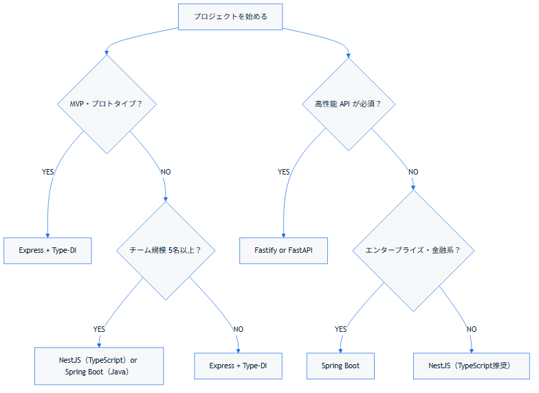

### 9.2.7 📋 チェックリスト

```
フレームワーク選定
✅ プロジェクト規模を判定
✅ チーム経験度を考慮
✅ 学習曲線を確認
✅ エコシステム・ライブラリを調査
✅ 本番運用実績を確認
✅ DI・Validation が組み込まれているか
✅ テスティングサポートを確認
```

**次: DI コンテナ →**

## 9.3 DI コンテナー・IoC フレームワーク

依存関係管理ツールの比較と実装方法。

### 9.3.1 🎯 DI コンテナーの役割

```
DI コンテナー = 自動依存関係管理ツール

機能：
  1. オブジェクトの生成（インスタンス化）
  2. 依存関係の自動注入
  3. ライフサイクル管理（singleton, 一時的など）
  4. 循環依存の検出
```

### 9.3.2 🔷 TypeScript 推奨 3選

#### 9.3.2.1 ① Type-DI（最もシンプル）

**推奨度：⭐⭐⭐⭐⭐（初心者向け）**

```typescript
npm install typedi reflect-metadata

// reflect-metadata を最初に import
import 'reflect-metadata';
import { Container, Service, Inject } from 'typedi';

// サービスの定義
@Service()
export class UserRepository {
  async getById(id: string) {
    // DB接続などの実装
  }
}

@Service()
export class UserService {
  // 自動で UserRepository が注入される
  constructor(
    @Inject() private userRepository: UserRepository
  ) {}

  async getUser(id: string) {
    return this.userRepository.getById(id);
  }
}

// 使用
const userService = Container.get(UserService);
```

**メリット：** - セットアップが簡単 - デコレータベース（読みやすい） - TypeScript ネイティブ

**デメリット：** - 複雑な設定には向かない - インターフェース型の注入が難しい

**適用場面：** - Express + DI の組み合わせ - 小〜中規模プロジェクト

#### 9.3.2.2 ② InversifyJS（複雑な設定向け）

**推奨度：⭐⭐⭐⭐☆（大規模向け）**

```typescript
npm install inversify reflect-metadata
npm install --save-dev @types/inversify

import 'reflect-metadata';
import { Container, injectable, inject } from 'inversify';

// インターフェース定義
interface IUserRepository {
  getById(id: string): Promise<User>;
}

// 実装
@injectable()
export class MySQLUserRepository implements IUserRepository {
  async getById(id: string) {
    // DB接続
  }
}

@injectable()
export class UserService {
  constructor(
    @inject('UserRepository')
    private userRepository: IUserRepository
  ) {}

  async getUser(id: string) {
    return this.userRepository.getById(id);
  }
}

// 設定
const TYPES = {
  UserRepository: Symbol.for('UserRepository'),
  UserService: Symbol.for('UserService')
};

const container = new Container();
container.bind<IUserRepository>(TYPES.UserRepository)
  .to(MySQLUserRepository);
container.bind<UserService>(TYPES.UserService)
  .to(UserService);

// 使用
const userService = container.get<UserService>(TYPES.UserService);
```

**メリット：** - インターフェース型の注入が容易 - 複雑な設定に対応 - Transient / Singleton 詳細制御

**デメリット：** - セットアップが複雑 - Symbol を使った設定が煩雑

**適用場面：** - マイクロサービス - プラグインアーキテクチャ

#### 9.3.2.3 ③ Awilix（関数型好み向け）

**推奨度：⭐⭐⭐⭐☆（関数型プログラミング向け）**

```typescript
npm install awilix

import { createContainer, asClass, asFunction } from 'awilix';

const container = createContainer();

// 登録パターン色々
container.register({
  // ✅ Singleton（1回だけ作成）
  userRepository: asClass(MySQLUserRepository).singleton(),

  // ✅ Transient（毎回作成）
  userService: asClass(UserService).transient(),

  // ✅ Factory function
  config: asFunction(() => ({
    dbUrl: process.env.DATABASE_URL
  })).singleton(),

  // ✅ Value
  logger: asValue(console)
});

// 自動解決（引数名で依存関係を判定）
class UserService {
  constructor(userRepository, config, logger) {
    this.userRepository = userRepository;
    this.config = config;
    this.logger = logger;
  }
}

// 使用
const { userService } = container.cradle;
```

**メリット：** - 設定がシンプル（引数名がキー） - オブジェクト分割代入で使える - Fastify と相性良い

**デメリット：** - 引数名に依存（リファクタリングで不可視） - 型安全性が低い（any）

**適用場面：** - Fastify プロジェクト - 小〜中規模 CLI - 関数型プログラミング重視

### 9.3.3 🟠 Java 推奨 2選

#### 9.3.3.1 ① Spring DI（Spring Boot 組み込み）

**推奨度：⭐⭐⭐⭐⭐（標準）**

```java
import org.springframework.stereotype.Service;
import org.springframework.beans.factory.annotation.Autowired;

@Service
public class UserRepository {
  // DB 接続コード
}

@Service
public class UserService {
  // 自動で UserRepository が注入される
  @Autowired
  private UserRepository userRepository;

  public User getUser(String id) {
    return userRepository.getById(id);
  }
}

// または コンストラクタ注入（推奨）
@Service
public class UserService {
  private final UserRepository userRepository;

  @Autowired
  public UserService(UserRepository userRepository) {
    this.userRepository = userRepository;
  }
}

// 使用
@Configuration
public class AppConfig {
  @Bean
  public UserRepository userRepository() {
    return new MySQLUserRepository();
  }

  @Bean
  public UserService userService(UserRepository repo) {
    return new UserService(repo);
  }
}
```

**メリット：** - Spring Boot に統合 - 大規模エコシステム - 成熟度が最高

**デメリット：** - 自動配線の魔法性（追跡困難） - セットアップが複雑

#### 9.3.3.2 ② Guice（軽量代替）

**推奨度：⭐⭐⭐⭐☆（軽量志向）**

```java
import com.google.inject.*;

// インターフェース定義
public interface UserRepository {
  User getById(String id);
}

// 実装
public class MySQLUserRepository implements UserRepository {
  public User getById(String id) { ... }
}

@Singleton
public class UserService {
  private final UserRepository repo;

  @Inject
  public UserService(UserRepository repo) {
    this.repo = repo;
  }
}

// 設定
public class AppModule extends AbstractModule {
  @Override
  protected void configure() {
    bind(UserRepository.class)
      .to(MySQLUserRepository.class)
      .in(Scopes.SINGLETON);

    bind(UserService.class);
  }
}

// 使用
Injector injector = Guice.createInjector(new AppModule());
UserService service = injector.getInstance(UserService.class);
```

**メリット：** - Spring より軽量 - 設定が明示的 - 小規模プロジェクトに最適

**デメリット：** - Spring Boot より機能が少ない - エコシステムが小さい

### 9.3.4 🐍 Python 推奨

#### 9.3.4.1 Dependency Injector

**推奨度：⭐⭐⭐⭐☆**

```python
from dependency_injector import containers, providers

class Container(containers.DeclarativeContainer):
    # Config
    config = providers.Configuration()

    # Repositories
    user_repository = providers.Singleton(
        UserRepository,
        db_url=config.db.url
    )

    # Services
    user_service = providers.Factory(
        UserService,
        repository=user_repository
    )

# 使用
container = Container()
user_service = container.user_service()
```

### 9.3.5 📊 DI コンテナー比較表

| 項目 | Type-DI | InversifyJS | Awilix | Spring | Guice |
| --- | --- | --- | --- | --- | --- |
| **学習曲線** | ⭐ | ⭐⭐⭐ | ⭐⭐ | ⭐⭐⭐ | ⭐⭐ |
| **セットアップ** | ⭐ | ⭐⭐ | ⭐ | ⭐⭐⭐ | ⭐⭐ |
| **複雑設定対応** | ⭐⭐ | ⭐⭐⭐⭐⭐ | ⭐⭐⭐ | ⭐⭐⭐⭐⭐ | ⭐⭐⭐⭐ |
| **型安全性** | ⭐⭐⭐⭐⭐ | ⭐⭐⭐⭐⭐ | ⭐⭐ | ⭐⭐⭐⭐⭐ | ⭐⭐⭐⭐⭐ |
| **エコシステム** | ⭐⭐⭐⭐ | ⭐⭐⭐⭐ | ⭐⭐⭐ | ⭐⭐⭐⭐⭐ | ⭐⭐⭐⭐ |

### 9.3.6 🎯 選定フロー

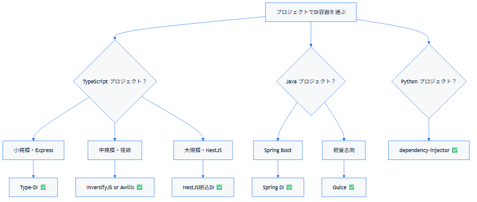

### 9.3.7 📋 チェックリスト

```
DI設定
✅ 循環依存がない
✅ ライフサイクル（Singleton/Transient）が適切
✅ 自動解決可能か明示的かが一貫
✅ テストでモック化可能

設定管理
✅ 本番・開発で設定を切り替え
✅ 環境変数から読み込み
✅ 設定がシングルソース・オブ・トゥルース（SSOT）
```

**次: 開発ツール →**

## 9.4 開発ツール（テスト・分析・ビルド）

プロジェクト品質を高めるための開発支援ツール。

### 9.4.1 🧪 テストツール

#### 9.4.1.1 ユニットテスト：Jest（Node.js 標準）

```bash
npm install --save-dev jest @types/jest ts-jest

# jest.config.js
module.exports = {
  preset: 'ts-jest',
  testEnvironment: 'node',
  roots: ['<rootDir>/src'],
  testMatch: ['**/__tests__/**/*.ts', '**/?(*.)+(spec|test).ts'],
  collectCoverageFrom: [
    'src/**/*.ts',
    '!src/**/*.interface.ts',
    '!src/main.ts'
  ],
  coverageThreshold: {
    global: {
      branches: 75,
      functions: 80,
      lines: 80,
      statements: 80
    }
  }
};
```

**テスト例：ドメイン層**

```typescript
// src/domain/Email.test.ts
describe('Email', () => {
  it('should validate email format', () => {
    expect(() => new Email('invalid')).toThrow(InvalidEmailError);
    expect(() => new Email('valid@example.com')).not.toThrow();
  });

  it('should normalize email', () => {
    const email = new Email('USER@EXAMPLE.COM');
    expect(email.getValue()).toBe('user@example.com');
  });
});

describe('Money', () => {
  it('should not allow negative amounts', () => {
    expect(() => new Money(-100)).toThrow();
  });

  it('should add amounts correctly', () => {
    const m1 = new Money(100);
    const m2 = new Money(50);
    expect(m1.add(m2).value).toBe(150);
  });

  it('should throw error when subtracting more than available', () => {
    const m1 = new Money(100);
    const m2 = new Money(150);
    expect(() => m1.subtract(m2)).toThrow();
  });
});
```

**テスト例：ユースケース層（Mock利用）**

```typescript
// src/application/CreateUserUseCase.test.ts
describe('CreateUserUseCase', () => {
  let useCase: CreateUserUseCase;
  let mockUserRepository: jest.Mocked<UserRepository>;
  let mockEmailService: jest.Mocked<EmailService>;

  beforeEach(() => {
    // Mock 実装
    mockUserRepository = {
      save: jest.fn(),
      getByEmail: jest.fn(),
      getById: jest.fn(),
      findAll: jest.fn()
    };

    mockEmailService = {
      send: jest.fn()
    };

    useCase = new CreateUserUseCase(
      mockUserRepository,
      mockEmailService
    );
  });

  it('should create user successfully', async () => {
    const request = {
      email: 'user@example.com',
      password: 'StrongPass123!',
      name: 'John Doe'
    };

    mockUserRepository.getByEmail.mockResolvedValue(null);

    const response = await useCase.execute(request);

    expect(response.userId).toBeDefined();
    expect(mockUserRepository.save).toHaveBeenCalledWith(
      expect.objectContaining({
        email: expect.any(Email)
      })
    );
    expect(mockEmailService.send).toHaveBeenCalledWith(
      'user@example.com',
      expect.stringContaining('Welcome')
    );
  });

  it('should throw error if user already exists', async () => {
    const request = {
      email: 'existing@example.com',
      password: 'StrongPass123!',
      name: 'Existing User'
    };

    mockUserRepository.getByEmail.mockResolvedValue(
      new User('1', new Email('existing@example.com'), 'Existing User')
    );

    await expect(useCase.execute(request)).rejects.toThrow(
      UserAlreadyExistsError
    );
  });
});
```

**実行コマンド**

```bash
npm test                    # すべてのテスト実行
npm test -- --coverage     # カバレッジ計測
npm test -- --watch        # ウォッチモード
npm test -- --bail         # 最初の失敗で停止
```

#### 9.4.1.2 統合テスト：Supertest（HTTP テスト）

```typescript
// src/presentation/controllers/UserController.test.ts
import request from 'supertest';
import { createApp } from '../../../app';

describe('GET /users/:id', () => {
  let app: Express.Application;

  beforeAll(() => {
    app = createApp();
  });

  it('should return user by id', async () => {
    const response = await request(app)
      .get('/users/1')
      .expect(200);

    expect(response.body).toHaveProperty('id', '1');
    expect(response.body).toHaveProperty('email');
  });

  it('should return 404 for non-existent user', async () => {
    await request(app)
      .get('/users/999')
      .expect(404);
  });
});

describe('POST /users', () => {
  let app: Express.Application;

  beforeAll(() => {
    app = createApp();
  });

  it('should create user with valid data', async () => {
    const response = await request(app)
      .post('/users')
      .send({
        email: 'newuser@example.com',
        password: 'StrongPass123!',
        name: 'New User'
      })
      .expect(201);

    expect(response.body).toHaveProperty('id');
  });

  it('should return 422 for invalid email', async () => {
    await request(app)
      .post('/users')
      .send({
        email: 'invalid-email',
        password: 'StrongPass123!',
        name: 'User'
      })
      .expect(422);
  });
});
```

#### 9.4.1.3 E2E テスト：TestContainers（本物の DB でテスト）

```typescript
// integration test with real database
import { GenericContainer, StartedTestContainer } from 'testcontainers';

describe('User Integration Tests', () => {
  let container: StartedTestContainer;
  let connection: mysql.Connection;

  beforeAll(async () => {
    // MySQL コンテナ起動
    container = await new GenericContainer('mysql:8')
      .withExposedPorts(3306)
      .withEnvironment({
        MYSQL_ROOT_PASSWORD: 'root',
        MYSQL_DATABASE: 'test_db'
      })
      .start();

    const host = container.getHost();
    const port = container.getMappedPort(3306);

    // コネクション作成
    connection = await mysql.createConnection({
      host,
      port,
      user: 'root',
      password: 'root',
      database: 'test_db'
    });

    // スキーマ実行
    await connection.query(`
      CREATE TABLE users (
        id VARCHAR(36) PRIMARY KEY,
        email VARCHAR(255) UNIQUE NOT NULL,
        password_hash VARCHAR(255) NOT NULL
      )
    `);
  });

  afterAll(async () => {
    await connection.end();
    await container.stop();
  });

  it('should save and retrieve user from DB', async () => {
    const userRepository = new MySQLUserRepository(connection);
    const user = new User('1', new Email('test@example.com'), 'Test User');

    await userRepository.save(user);
    const retrieved = await userRepository.getById('1');

    expect(retrieved).toBeDefined();
    expect(retrieved?.email.getValue()).toBe('test@example.com');
  });
});
```

### 9.4.2 📊 コード品質ツール

#### 9.4.2.1 静的解析：ESLint + TypeScript Plugin

```bash
npm install --save-dev eslint @typescript-eslint/eslint-plugin @typescript-eslint/parser

# .eslintrc.json
{
  "parser": "@typescript-eslint/parser",
  "plugins": ["@typescript-eslint"],
  "extends": ["plugin:@typescript-eslint/recommended"],
  "rules": {
    "no-console": "warn",
    "prefer-const": "error",
    "@typescript-eslint/explicit-function-return-types": "error",
    "@typescript-eslint/no-explicit-any": "error"
  },
  "env": {
    "node": true,
    "es2022": true
  }
}

npx eslint src/**/*.ts
```

#### 9.4.2.2 循環依存検出：madge

```bash
npm install --save-dev madge

# 循環依存を検出
npx madge --circular src/

# グラフを画像出力
npx madge --image graph.png src/

# 詳細情報
npx madge --list src/
```

#### 9.4.2.3 セキュリティスキャン：Snyk

```bash
npm install --save-dev snyk

# 脆弱性をスキャン
npx snyk test

# 修正提案を表示
npx snyk fix
```

### 9.4.3 🔨 ビルド・パッケージング

#### 9.4.3.1 TypeScript コンパイル

```bash
npm install --save-dev typescript

# tsconfig.json
{
  "compilerOptions": {
    "target": "ES2020",
    "module": "commonjs",
    "lib": ["ES2020"],
    "outDir": "./dist",
    "rootDir": "./src",
    "strict": true,
    "esModuleInterop": true,
    "skipLibCheck": true,
    "forceConsistentCasingInFileNames": true,
    "resolveJsonModule": true,
    "sourceMap": true,
    "declaration": true
  }
}

# コンパイル
npx tsc

# package.json scripts
{
  "scripts": {
    "build": "tsc",
    "start": "node dist/main.js",
    "dev": "ts-node src/main.ts"
  }
}
```

### 9.4.4 📈 パフォーマンス計測

#### 9.4.4.1 Clinic.js（本番問題診断）

```bash
npm install --save-dev clinic

# CPU, メモリ, 遅延を計測
clinic doctor -- npm start

# グラフで可視化
clinic doctor -- npm test
```

### 9.4.5 📋 チェックリスト

```
テスト
✅ ユニットテスト：80%+ カバレッジ
✅ 統合テスト：主要フロー
✅ E2E テスト：ユーザーシナリオ
✅ テストが CI/CD に統合

品質
✅ ESLint で文法チェック
✅ 循環依存なし（madge）
✅ セキュリティスキャン（Snyk）
✅ パフォーマンスモニタリング

ビルド
✅ TypeScript コンパイルエラーなし
✅ ビルドサイズが許容範囲
✅ ソースマップが生成
```

**次: 学習リソース →**

## 9.5 学習リソース

Clean Architecture と DDD の学習に役立つ本、コース、コミュニティ。

### 9.5.1 📚 必読書籍

#### 9.5.1.1 第1順位：「Clean Architecture」 Robert C. Martin

```
タイトル: Clean Architecture:
          A Craftsman's Guide to Software Structure and Design

著者: Robert C. Martin（Uncle Bob）
出版社: Prentice Hall
初版: 2017年
言語: 英語・日本語
推奨度: ⭐⭐⭐⭐⭐

内容：
- Clean Architecture の背景・哲学
- 5つの層
  （データ、境界、ユースケース、エンティティ、フレームワーク）
- 依存関係の方向（外 → 内）
- 実装パターン・テスト戦略

いつ読むべき？
→ Clean Architecture を理解し始めたら必読

Amazon リンク：
https://amazon.co.jp/s?k=Clean+Architecture+Robert+Martin
```

#### 9.5.1.2 第2順位：「Domain-Driven Design」Eric Evans

```
タイトル: Domain-Driven Design:
          Tackling Complexity in the Heart of Software

著者: Eric Evans
出版社: Addison-Wesley
初版: 2003年
言語: 英語・日本語
推奨度: ⭐⭐⭐⭐⭐

内容：
- Ubiquitous Language（共通言語）
- Bounded Context（境界のあるコンテキスト）
- エンティティ・値オブジェクト設計
- ドメインサービス・リポジトリ
- ドメイン駆動型アーキテクチャ

いつ読むべき？
→ ドメイン層設計が複雑になったら

Amazon リンク：
https://amazon.co.jp/s?k=Domain-Driven+Design+Eric+Evans
```

#### 9.5.1.3 第3順位：「Building Microservices」Sam Newman

```
タイトル: Building Microservices:
          Designing Fine-Grained Systems (2nd Edition)

著者: Sam Newman
出版社: O'Reilly Media
初版: 2015年（第2版: 2021年）
言語: 英語・日本語
推奨度: ⭐⭐⭐⭐★

内容：
- サービス分割戦略
- サービス間通信（RESTful, gRPC, イベント駆動）
- 分散トランザクション・Saga パターン
- デプロイ・監視・トレーシング

いつ読むべき？
→ マイクロサービス化を検討する場面

Amazon リンク：
https://amazon.co.jp/s?k=Building+Microservices+Sam+Newman
```

#### 9.5.1.4 番外編：「Refactoring」Martin Fowler

```
タイトル: Refactoring: Improving the Design of Existing Code (2nd Edition)

著者: Martin Fowler
出版社: Addison-Wesley
初版: 1999年（第2版: 2018年）
推奨度: ⭐⭐⭐⭐★

内容：
- リファクタリング手法
- テスト駆動開発との組み合わせ
- コード臭い（Code Smells）の検出
- 段階的な設計改善

いつ読むべき？
→ 既存コードをクリーンアップしたい時
```

### 9.5.2 🎓 オンラインコース

#### 9.5.2.1 Udemy

```
コース1: "Clean Architecture: Applying Domain Driven Design"
講師: Mosh Hamedani
対象: JavaScript/TypeScript
価格: $14.99 - $99.99
推奨度: ⭐⭐⭐⭐⭐

特徴：
- 実装中心
- 日本語字幕あり
- 4時間のビデオ
- 演習付き

Link: https://www.udemy.com/courses/search/?q=Clean%20Architecture
```

#### 9.5.2.2 Pluralsight

```
コース1: "Clean Code: Writing Code for Humans"
講師: Cory House
対象: C# / Java / JavaScript
推奨度: ⭐⭐⭐⭐★

特徴：
- 多言語対応
- テスト駆動開発
- リファクタリング
- 実装例豊富

---

コース2: "Microservices Architecture"
講師: Sam Newman
対象: Java / Go / Python
推奨度: ⭐⭐⭐⭐★

特徴：
- マイクロサービス設計
- 実装パターン
- トラブルシューティング
```

### 9.5.3 📝 ブログ・記事

#### 9.5.3.1 Uncle Bob’s Blog

```
URL: https://blog.cleancoder.com/

主要記事：
- "The Clean Architecture"
- "Screaming Architecture"
- "The Dependency Rule"

更新頻度: 月1-2回
対象: エンジニア全般
```

#### 9.5.3.2 Martin Fowler’s Blog

```
URL: https://martinfowler.com/

主要セクション：
- Articles（建築パターン・デザイン）
- Microservices（マイクロサービス）
- Testing（テスト戦略）

推奨記事：
- "Microservice Prerequisites"
- "Event Sourcing"
- "CQRS"

更新頻度: 月2-3回
対象: アーキテクト・Lead Engineer
```

#### 9.5.3.3 DDD Community

```
URL: https://dddcommunity.org/

コンテンツ：
- Domain-Driven Design の解説
- 実装パターン
- ケーススタディ
- コミュニティイベント

推奨：
- "DDD in a Nutshell"
- "Bounded Contexts"
- ドメインモデリングワークショップ
```

### 9.5.4 🏢 実装テンプレート・サンプル

#### 9.5.4.1 GitHub リポジトリ

##### 9.5.4.1.1 ① clean-architecture-manga

```
Repository: https://github.com/ivanpaulovich/clean-architecture-manga

特徴：
- .NET 6 / C# 10 + React + Redux による実装例（アプリ名が「Manga」）
- ユースケースを中心とした構成、フレームワークから独立
- テスト容易性を重視した設計
- 言語: 英語
```

##### 9.5.4.1.2 ② clean-node-api

```
Repository: https://github.com/rmanguinho/clean-node-api

特徴：
- Node.js + Express + Clean Architecture
- 完全な実装例
- テストカバレッジ計測（Coveralls連携）
- CI/CD パイプライン

フォルダ構造：
src/
├─ domain/
├─ presentation/
├─ data/（データベース層）
├─ main/（Bootstrap）
└─ validation/

対象: JavaScript
```

##### 9.5.4.1.3 ③ typescript-clean-architecture

```
Repository: https://github.com/pvarentsov/typescript-clean-architecture

特徴：
- TypeScript + NestJS + TypeORM
- 投稿・メディア管理アプリを題材にした実装例
- レイヤー分割の参考実装

対象: TypeScript/NestJS
```

#### 9.5.4.2 プロジェクト生成コマンド

```bash
# Express + Clean Architecture テンプレート
npx create-clean-app my-app

# NestJS + 標準的なフォルダ構造
nest new my-app
cd my-app
nest generate module users
nest generate service domain/users/user.service
```

### 9.5.5 💬 コミュニティ

#### 9.5.5.1 チャット・フォーラム

```
Slack チャンネル：
- DDD Community Slack
  → dddcommunity.org 等から招待リンクを確認
  メンバー: 12,000+ (2024)

Discord サーバー：
- Node.js Japan
  → 公式サイト・SNS で招待リンクを確認
  主催: Node.js コミュニティ

Reddit（英語）：
- r/webdev
  → https://reddit.com/r/webdev
- r/typescript
  → https://reddit.com/r/typescript
```

#### 9.5.5.2 GitHub Discussions

```
クリーンアーキテクチャに関する質問：
- clean-architecture リポジトリの Discussions
- Node.js/TypeScript 関連リポジトリ

投稿例：
- ベストプラクティス相談
- アーキテクチャレビュー
- 設計パターン質問
```

### 9.5.6 🎉 カンファレンス

#### 9.5.6.1 Node.js・Web 系

```
📅 JSConf JP
   会期: 毎年11月
   開催地: 日本（東京/大阪）
   URL: https://jsconf.jp/
   特徴: 国内最大級 JavaScript カンファレンス

📅 NodeFest
   会期: 毎年9月
   開催地: 日本
   特徴: Node.js 専門

📅 Web Directions Summit
   会期: 毎年12月
   開催地: オーストラリア（オンライン参加可）
   特徴: Web design・フロントエンド
```

#### 9.5.6.2 アーキテクチャ・システム設計

```
📅 CraftConf
   会期: 毎年4月
   開催地: ハンガリー・ブダペスト
   URL: https://craft-conf.com/
   特徴: アーキテクチャ・デザイン重視

📅 DDD Europe
   会期: 毎年10月
   開催地: バルセロナ（オンライン開催も）
   URL: https://dddeurope.com/
   特徴: Domain-Driven Design 専門

📅 GOTO Conferences
   会期: 通年開催
   開催地: 複数地点
   URL: https://gotocon.com/
   特徴: トップエンジニアの講演
```

### 9.5.7 📋 学習パス

#### 9.5.7.1 ビギナー向け（週１時間 × 4 週間）

```
Week 1: 基礎理解
   - 「Clean Architecture」 の概要（YouTube動画5分）
   - Udemy コース第1〜3章

Week 2: ドメイン層
   - Domain-Driven Design 初章
   - 値オブジェクト・エンティティの実装

Week 3: 実装
   - サンプルリポジトリ（clean-architecture-manga）を読む
   - 簡単な CRUD アプリを実装

Week 4: テスト・チューニング
   - ユニットテスト・統合テスト実装
   - コードレビュー・改善
```

#### 9.5.7.2 中級者向け（週２時間 × 8 週間）

```
Week 1-2: 「Clean Architecture」 完読
Week 3-4: 「Domain-Driven Design」 第一部
Week 5-6: 実装テンプレート徹底研究
Week 7-8: マイクロサービス設計（Building Microservices）
```

### 9.5.8 📋 チェックリスト

```
学習リソース選定
✅ 自分の現在レベルを把握
✅ 目標（基礎/実装/アーキテクチャ設計）を明確化
✅ 本・動画・コミュニティをバランスよく利用
✅ 定期的に実装して手を動かす
✅ コミュニティで他者の知見を吸収

知識定着
✅ インプット後に実装練習
✅ 同僚にアウトプット・説明
✅ プロジェクトで実践
✅ 定期的に見直し
```

**完了！ Clean Architecture マスターへようこそ 🎓**

**次のアクション：** 1. 推奨書籍を1冊選んで読む 2. サンプルリポジトリをクローンして研究 3. 小規模プロジェクトで実装してみる 4. コミュニティに参加して知見共有

**本ガイドの各セクションをもう一度確認：** - 実装ガイド ← 実装開始 - ベストプラクティス ← 品質向上 - よくある間違い ← アンチパターン回避 - ケーススタディ ← 実装例学習